# MiND Reliability: Manuscript Analysis

2026-10-06

This document is the single source of truth for every analysis, table, and figure reported in the manuscript. It reads the raw data, applies the two motion-exclusion rules, builds the analytic datasets, fits every inferential model, runs the magnitude bootstrap, and renders every manuscript figure, in one pass from top to bottom, written out sequentially rather than hidden behind helper functions. Nothing reported in the manuscript is computed anywhere else.

Two helper files hold code that is purely mechanical repetition rather than analysis – the 5,000-draw bootstrap resampling loop (`R/bootstrap.R`) and the ggplot/gtable construction for the two figures (`R/plot_helpers.R`). Both are long and fiddly for reasons that have nothing to do with the statistics, so they are kept out of the way; everything else – the raw-data inclusion rules, the motion-exclusion rules, the person-mean age decomposition, the modality contrasts, every model formula, and every manuscript table – is written out directly below, one rule (primary, then liberal) at a time.

# 1 Setup

```r
required_packages <- c("here", "tidyverse", "lme4", "lmerTest", "ggh4x", "gtable", "scales")
missing_packages <- required_packages[
  !vapply(required_packages, requireNamespace, logical(1), quietly = TRUE)
]
if (length(missing_packages) > 0) {
  stop("Install these packages before running this document: ",
       paste(missing_packages, collapse = ", "))
}

suppressPackageStartupMessages({
  library(here)
  library(tidyverse)
  library(lme4)
  library(lmerTest)
  library(ggh4x)
  library(grid)   # textGrob()/nullGrob(), used by R/plot_helpers.R
})

# here() searches upward from the working directory for MiND-Reliability.Rproj,
# so every path below is relative to the project root regardless of whether
# this document is knit, run(), or stepped through interactively -- no
# absolute local paths anywhere in this document.
RAW_DATA_DIR <- here("data", "raw")
TABLE_DIR <- here("output", "tables")
FIGURE_DIR <- here("output", "figures")
dir.create(TABLE_DIR, showWarnings = FALSE, recursive = TRUE)
dir.create(FIGURE_DIR, showWarnings = FALSE, recursive = TRUE)

# ---------------------------------------------------------------------------
# The manuscript specification, fixed here and used everywhere below.
# ---------------------------------------------------------------------------
OUTCOMES <- c("Distinctiveness", "Reliability", "Confusability")
MODEL_TERMS <- c("within_cAge", "between_cAge", "Sex_M1", "Education", "aud_mot", "aud_vis")
AGE_TERMS <- c("between_cAge", "within_cAge")
OLDER_ADULT_AGE <- 65          # between_cAge is centred here

RULE_LABEL_PRIMARY <- "FD 0.4 mm / 10% (primary)"
RULE_LABEL_LIBERAL <- "FD 0.5 mm / 20% (liberal)"

MAGNITUDE_BOOT_DRAWS <- 5000L
MAGNITUDE_BOOT_SEED <- 20260910L

source(here("R", "bootstrap.R"))     # participant-cluster bootstrap helper
source(here("R", "plot_helpers.R"))  # ggplot construction for Figures 2/3/S1/S2
```

# 2 Load raw inputs

Exactly four files are read from `data/raw/`, and nothing else. The study master sheets (`CombinedMasterGLX_*`) are not part of this repository and are not needed to reproduce any result here.

```r
required_raw_files <- c(
  "df_mind_all_mc04.csv", "df_mind_all.csv",
  "motion_exclusion_by_run_4mm.csv", "motion_exclusion_by_run_5mm.csv"
)
missing_files <- required_raw_files[
  !file.exists(file.path(RAW_DATA_DIR, required_raw_files))
]
if (length(missing_files) > 0) {
  stop("Missing required raw files in ", RAW_DATA_DIR, ": ",
       paste(missing_files, collapse = ", "))
}

# num_threads = 1 is deliberate: the multi-threaded readr parser segfaults on
# these files.
#
# df_mind_all_mc04.csv is outcomes from the FD 0.4 mm scrubbing pipeline (used
# by the primary rule); df_mind_all.csv is the FD 0.5 mm pipeline (liberal
# rule). Each is keyed to the run-level motion file at the matching cutoff.
outcomes_raw_fd04 <- readr::read_csv(
  file.path(RAW_DATA_DIR, "df_mind_all_mc04.csv"), num_threads = 1, show_col_types = FALSE
)
outcomes_raw_fd05 <- readr::read_csv(
  file.path(RAW_DATA_DIR, "df_mind_all.csv"), num_threads = 1, show_col_types = FALSE
)
motion_fd04 <- readr::read_csv(
  file.path(RAW_DATA_DIR, "motion_exclusion_by_run_4mm.csv"), num_threads = 1, show_col_types = FALSE
)
motion_fd05 <- readr::read_csv(
  file.path(RAW_DATA_DIR, "motion_exclusion_by_run_5mm.csv"), num_threads = 1, show_col_types = FALSE
)

cat(sprintf(
  "Read %d + %d outcome rows and %d + %d motion records from data/raw/.\n",
  nrow(outcomes_raw_fd04), nrow(outcomes_raw_fd05), nrow(motion_fd04), nrow(motion_fd05)
))
```

```
## Read 398 + 398 outcome rows and 1613 + 1605 motion records from data/raw/.
```

# 3 Construct analysis datasets

Each outcome file is wide (one `{Modality}{Outcome}` column per modality-outcome pair); it is reshaped to one row per subject x wave x modality. Wave 3 is dropped here, before any motion accounting, so every later count is Waves 1-2 only – the exploratory three-wave MIND-C analysis is not part of this manuscript. The primary and liberal outcome files are reshaped separately and identically, since they feed two different motion rules below.

```r
outcomes_long_fd04 <- outcomes_raw_fd04 %>%
  filter(!is.na(SubNum)) %>%
  pivot_longer(
    cols = matches("^(Aud|Mot|Vis)(Distinctiveness|Reliability|Confusability)$"),
    names_to = c("Modality", ".value"),
    names_pattern = "(Aud|Mot|Vis)(.*)"
  ) %>%
  mutate(Modality = factor(Modality, levels = c("Aud", "Mot", "Vis"))) %>%
  filter(Wave_Num %in% c(1, 2))

outcomes_long_fd05 <- outcomes_raw_fd05 %>%
  filter(!is.na(SubNum)) %>%
  pivot_longer(
    cols = matches("^(Aud|Mot|Vis)(Distinctiveness|Reliability|Confusability)$"),
    names_to = c("Modality", ".value"),
    names_pattern = "(Aud|Mot|Vis)(.*)"
  ) %>%
  mutate(Modality = factor(Modality, levels = c("Aud", "Mot", "Vis"))) %>%
  filter(Wave_Num %in% c(1, 2))

# Subgroup == 1 identifies the healthy-subject cohort the manuscript analyzes.
# Both outcome files describe the same participants, so this is the same ID
# set either way; both are combined defensively.
healthy_subject_ids <- bind_rows(outcomes_long_fd04, outcomes_long_fd05) %>%
  filter(Subgroup == 1) %>%
  distinct(Subject) %>%
  pull(Subject)

# Used only for Table S3 (motion accounting), which breaks runs assessed down
# by age group.
subject_age_groups <- bind_rows(outcomes_long_fd04, outcomes_long_fd05) %>%
  filter(Subgroup == 1) %>%
  distinct(Subject, Age_DuringParticipation_) %>%
  transmute(
    Subject,
    Age_Group = factor(
      if_else(Age_DuringParticipation_ < OLDER_ADULT_AGE, "Young adults", "Older adults"),
      levels = c("Young adults", "Older adults")
    )
  )

cat(sprintf("%d healthy-cohort participants (Subgroup == 1).\n", length(healthy_subject_ids)))
```

```
## 313 healthy-cohort participants (Subgroup == 1).
```

# 4 Motion exclusion and accounting

Two motion-exclusion rules are applied to the run-level motion file at the matching FD cutoff:

| Rule | FD cutoff | Run excluded at |
| --- | --- | --- |
| primary | 0.4 mm | >= 10% scrubbed volumes |
| liberal | 0.5 mm | >= 20% scrubbed volumes |

A run is identified by subject x modality x session (`placebo`) x run (`001`); only the healthy cohort’s assessed runs are considered.

```r
run_flags_primary <- motion_fd04 %>%
  filter(
    subject %in% healthy_subject_ids,
    session == "placebo",
    run == "001",
    experiment %in% c("auditory", "visual", "motor")
  ) %>%
  transmute(
    Subject = subject,
    Modality = recode(experiment, auditory = "Aud", motor = "Mot", visual = "Vis"),
    pct_excluded,
    exclude = pct_excluded >= 10
  )

run_flags_liberal <- motion_fd05 %>%
  filter(
    subject %in% healthy_subject_ids,
    session == "placebo",
    run == "001",
    experiment %in% c("auditory", "visual", "motor")
  ) %>%
  transmute(
    Subject = subject,
    Modality = recode(experiment, auditory = "Aud", motor = "Mot", visual = "Vis"),
    pct_excluded,
    exclude = pct_excluded >= 20
  )
```

Joining outcomes to motion flags can leave a subject x modality row with NO matching motion record at all (`exclude` is `NA`, not `FALSE`). This handling has already been audited (see the note below) and is preserved exactly: a row with no run-level motion record is DROPPED, not retained. `!exclude` already drops `NA`, but the `!is.na(exclude)` test is written out so the intent is explicit.

```r
# Full assessed set (pre-Subgroup/Wave filter) is kept for the missing-record
# diagnostic below; the Subgroup == 1 filter is applied when the analytic
# datasets are built in the next section.
joined_fd04 <- outcomes_long_fd04 %>% left_join(run_flags_primary, by = c("Subject", "Modality"))
joined_fd05 <- outcomes_long_fd05 %>% left_join(run_flags_liberal, by = c("Subject", "Modality"))

missing_motion_primary <- joined_fd04 %>% filter(Subgroup == 1, is.na(exclude))
missing_motion_liberal <- joined_fd05 %>% filter(Subgroup == 1, is.na(exclude))

cat(sprintf(
  "Unmatched subject x modality x wave rows with no motion record: %d (primary), %d (liberal).\n",
  nrow(missing_motion_primary), nrow(missing_motion_liberal)
))
```

```
## Unmatched subject x modality x wave rows with no motion record: 84 (primary), 84 (liberal).
```

```r
cat(
  "These rows are excluded, not recovered or added: all three prepared outcomes\n",
  "are already absent for them under both rules, so admitting them would not\n",
  "add complete model observations. This policy and the join are unchanged\n",
  "from the audited analysis.\n"
)
```

```
## These rows are excluded, not recovered or added: all three prepared outcomes
##  are already absent for them under both rules, so admitting them would not
##  add complete model observations. This policy and the join are unchanged
##  from the audited analysis.
```

Table S3 (motion accounting: runs assessed and excluded, by age group and modality) is built from the full run-flag sets, before the Subgroup/Wave filter is applied to build the analytic datasets. Its construction is deferred to the Tables section below, alongside the other manuscript tables.

# 5 Age decomposition

The corrected person-mean decomposition is preserved exactly. Mean age is computed over **unique retained participant-wave observations**, not modality-level rows, so the number of modalities retained at a wave cannot influence a participant’s mean age:

```
age_by_wave <- distinct(SubNum, Wave_Num, Age_DuringParticipation_)
mean_age    <- mean(Age_DuringParticipation_)        # per participant
between_cAge <- mean_age - 65
within_cAge  <- Age_DuringParticipation_ - mean_age  # per wave
```

A one-wave participant therefore has `within_cAge == 0`; a participant observed at ages 70 and 74 has `mean_age = 72` and within-person ages -2 and +2, regardless of how many modalities survived motion exclusion at either wave. A worked example, checked before this is ever applied to real data:

```r
worked_example <- tibble(
  SubNum = c(1, 1, 1, 1, 2, 2),
  Wave_Num = c(1, 1, 1, 2, 2, 2),
  Age_DuringParticipation_ = c(70, 70, 70, 74, 60, 60),
  Modality = c("Aud", "Mot", "Vis", "Aud", "Aud", "Vis")
)

worked_example_age_by_wave <- worked_example %>%
  distinct(SubNum, Wave_Num, Age_DuringParticipation_) %>%
  group_by(SubNum) %>%
  mutate(mean_age = mean(Age_DuringParticipation_), n_waves = n()) %>%
  ungroup() %>%
  mutate(
    between_cAge = mean_age - OLDER_ADULT_AGE,
    within_cAge = Age_DuringParticipation_ - mean_age
  )

worked_example_checked <- worked_example %>%
  left_join(
    worked_example_age_by_wave %>%
      select(SubNum, Wave_Num, Age_DuringParticipation_, mean_age, within_cAge, between_cAge, n_waves),
    by = c("SubNum", "Wave_Num", "Age_DuringParticipation_")
  )
stopifnot(
  all(worked_example_checked$mean_age[worked_example_checked$SubNum == 1] == 72),
  identical(worked_example_checked$within_cAge, c(-2, -2, -2, 2, 0, 0))
)

# Dropping a modality at a retained wave must not move that wave's age terms,
# because mean age above is computed from distinct(SubNum, Wave_Num, Age) --
# before any modality-level row is ever counted.
worked_example_subset <- worked_example[c(1, 4, 5), ]
worked_example_subset_age_by_wave <- worked_example_subset %>%
  distinct(SubNum, Wave_Num, Age_DuringParticipation_) %>%
  group_by(SubNum) %>%
  mutate(mean_age = mean(Age_DuringParticipation_), n_waves = n()) %>%
  ungroup() %>%
  mutate(
    between_cAge = mean_age - OLDER_ADULT_AGE,
    within_cAge = Age_DuringParticipation_ - mean_age
  )
worked_example_subset_checked <- worked_example_subset %>%
  left_join(
    worked_example_subset_age_by_wave %>%
      select(SubNum, Wave_Num, Age_DuringParticipation_, mean_age, within_cAge, between_cAge, n_waves),
    by = c("SubNum", "Wave_Num", "Age_DuringParticipation_")
  )
stopifnot(identical(
  worked_example_subset_checked$within_cAge,
  worked_example_checked$within_cAge[c(1, 4, 5)]
))
cat("Worked example passed: mean age 72 for participant 1 (ages 70, 74); within-person ages -2/+2.\n")
```

```
## Worked example passed: mean age 72 for participant 1 (ages 70, 74); within-person ages -2/+2.
```

Applied to the motion-filtered data, primary rule:

```r
analysis_primary <- joined_fd04 %>%
  filter(!is.na(exclude), !exclude, Subgroup == 1)

age_by_wave_primary <- analysis_primary %>%
  distinct(SubNum, Wave_Num, Age_DuringParticipation_)
stopifnot(
  !anyNA(age_by_wave_primary),
  !anyDuplicated(age_by_wave_primary[c("SubNum", "Wave_Num")])
)

age_by_wave_primary <- age_by_wave_primary %>%
  group_by(SubNum) %>%
  mutate(mean_age = mean(Age_DuringParticipation_), n_waves = n()) %>%
  ungroup() %>%
  mutate(
    between_cAge = mean_age - OLDER_ADULT_AGE,
    within_cAge = Age_DuringParticipation_ - mean_age
  )

# Invariants the decomposition must satisfy: a one-wave participant has zero
# within-person age; a participant's within-person ages sum to zero around
# their own mean; between_cAge is a simple re-centring of mean_age and
# nothing else.
within_sums_primary <- tapply(age_by_wave_primary$within_cAge, age_by_wave_primary$SubNum, sum)
stopifnot(
  all(age_by_wave_primary$within_cAge[age_by_wave_primary$n_waves == 1] == 0),
  all(abs(within_sums_primary) < 1e-9),
  all(abs(age_by_wave_primary$between_cAge - (age_by_wave_primary$mean_age - OLDER_ADULT_AGE)) < 1e-9),
  all(abs(age_by_wave_primary$within_cAge -
    (age_by_wave_primary$Age_DuringParticipation_ - age_by_wave_primary$mean_age)) < 1e-9)
)

n_rows_before_age_join_primary <- nrow(analysis_primary)
analysis_primary <- analysis_primary %>%
  left_join(
    age_by_wave_primary %>%
      select(SubNum, Wave_Num, Age_DuringParticipation_, mean_age, within_cAge, between_cAge, n_waves),
    by = c("SubNum", "Wave_Num", "Age_DuringParticipation_")
  )
stopifnot(nrow(analysis_primary) == n_rows_before_age_join_primary)
```

Applied to the motion-filtered data, liberal rule (identical steps):

```r
analysis_liberal <- joined_fd05 %>%
  filter(!is.na(exclude), !exclude, Subgroup == 1)

age_by_wave_liberal <- analysis_liberal %>%
  distinct(SubNum, Wave_Num, Age_DuringParticipation_)
stopifnot(
  !anyNA(age_by_wave_liberal),
  !anyDuplicated(age_by_wave_liberal[c("SubNum", "Wave_Num")])
)

age_by_wave_liberal <- age_by_wave_liberal %>%
  group_by(SubNum) %>%
  mutate(mean_age = mean(Age_DuringParticipation_), n_waves = n()) %>%
  ungroup() %>%
  mutate(
    between_cAge = mean_age - OLDER_ADULT_AGE,
    within_cAge = Age_DuringParticipation_ - mean_age
  )

within_sums_liberal <- tapply(age_by_wave_liberal$within_cAge, age_by_wave_liberal$SubNum, sum)
stopifnot(
  all(age_by_wave_liberal$within_cAge[age_by_wave_liberal$n_waves == 1] == 0),
  all(abs(within_sums_liberal) < 1e-9),
  all(abs(age_by_wave_liberal$between_cAge - (age_by_wave_liberal$mean_age - OLDER_ADULT_AGE)) < 1e-9),
  all(abs(age_by_wave_liberal$within_cAge -
    (age_by_wave_liberal$Age_DuringParticipation_ - age_by_wave_liberal$mean_age)) < 1e-9)
)

n_rows_before_age_join_liberal <- nrow(analysis_liberal)
analysis_liberal <- analysis_liberal %>%
  left_join(
    age_by_wave_liberal %>%
      select(SubNum, Wave_Num, Age_DuringParticipation_, mean_age, within_cAge, between_cAge, n_waves),
    by = c("SubNum", "Wave_Num", "Age_DuringParticipation_")
  )
stopifnot(nrow(analysis_liberal) == n_rows_before_age_join_liberal)
```

# 6 Modality coding

Two numeric contrasts code modality exactly as specified, so a model with both terms estimates Auditory, Motor, and Visual as distinct levels without a factor:

```r
analysis_primary <- analysis_primary %>%
  mutate(
    aud_mot = case_when(Modality == "Aud" ~ -1, Modality == "Mot" ~ 1, TRUE ~ 0),
    aud_vis = case_when(Modality == "Aud" ~ -1, Modality == "Vis" ~ 1, TRUE ~ 0)
  )

analysis_liberal <- analysis_liberal %>%
  mutate(
    aud_mot = case_when(Modality == "Aud" ~ -1, Modality == "Mot" ~ 1, TRUE ~ 0),
    aud_vis = case_when(Modality == "Aud" ~ -1, Modality == "Vis" ~ 1, TRUE ~ 0)
  )

stopifnot(
  all(analysis_primary$aud_mot[analysis_primary$Modality == "Aud"] == -1),
  all(analysis_primary$aud_mot[analysis_primary$Modality == "Mot"] == 1),
  all(analysis_primary$aud_mot[analysis_primary$Modality == "Vis"] == 0),
  all(analysis_primary$aud_vis[analysis_primary$Modality == "Aud"] == -1),
  all(analysis_primary$aud_vis[analysis_primary$Modality == "Vis"] == 1),
  all(analysis_primary$aud_vis[analysis_primary$Modality == "Mot"] == 0)
)
```

# 7 Sample checks

Sample sizes are checked against the audited analysis (`comparison_report.md` in the archived `old/age_correction/` snapshot) as a regression check: if the raw inputs or the exclusion logic ever changed, these counts would move and this chunk would fail. `returner_ids_primary`/`returner_ids_liberal` computed here are reused below when the Wave-1-anchored table samples are built.

```r
session_rows_primary <- analysis_primary %>% distinct(SubNum, Wave_Num)
wave1_ids_primary <- session_rows_primary$SubNum[session_rows_primary$Wave_Num == 1]
wave2_ids_primary <- session_rows_primary$SubNum[session_rows_primary$Wave_Num == 2]
returner_ids_primary <- intersect(wave1_ids_primary, wave2_ids_primary)

n_observations_primary <- nrow(analysis_primary)
n_sessions_primary <- nrow(session_rows_primary)
n_participants_primary <- n_distinct(analysis_primary$SubNum)
n_returners_primary <- length(returner_ids_primary)
n_wave1_sessions_primary <- sum(session_rows_primary$Wave_Num == 1)
n_wave2_sessions_primary <- sum(session_rows_primary$Wave_Num == 2)
n_wave2_only_primary <- length(setdiff(wave2_ids_primary, wave1_ids_primary))

cat(sprintf(
  "Primary: %d observations, %d sessions, %d participants, %d returners, %d Wave-1 sessions, %d Wave-2 sessions, %d Wave-2-only participants.\n",
  n_observations_primary, n_sessions_primary, n_participants_primary, n_returners_primary,
  n_wave1_sessions_primary, n_wave2_sessions_primary, n_wave2_only_primary
))
```

```
## Primary: 724 observations, 276 sessions, 218 participants, 58 returners, 217 Wave-1 sessions, 59 Wave-2 sessions, 1 Wave-2-only participants.
```

```r
stopifnot(
  n_observations_primary == 724,
  n_sessions_primary == 276,
  n_participants_primary == 218,
  n_returners_primary == 58,
  n_wave1_sessions_primary == 217,
  n_wave2_sessions_primary == 59,
  n_wave2_only_primary == 1
)
```

```r
session_rows_liberal <- analysis_liberal %>% distinct(SubNum, Wave_Num)
wave1_ids_liberal <- session_rows_liberal$SubNum[session_rows_liberal$Wave_Num == 1]
wave2_ids_liberal <- session_rows_liberal$SubNum[session_rows_liberal$Wave_Num == 2]
returner_ids_liberal <- intersect(wave1_ids_liberal, wave2_ids_liberal)

n_observations_liberal <- nrow(analysis_liberal)
n_sessions_liberal <- nrow(session_rows_liberal)
n_participants_liberal <- n_distinct(analysis_liberal$SubNum)
n_returners_liberal <- length(returner_ids_liberal)
n_wave1_sessions_liberal <- sum(session_rows_liberal$Wave_Num == 1)
n_wave2_sessions_liberal <- sum(session_rows_liberal$Wave_Num == 2)
n_wave2_only_liberal <- length(setdiff(wave2_ids_liberal, wave1_ids_liberal))

cat(sprintf(
  "Liberal: %d observations, %d sessions, %d participants, %d returners, %d Wave-1 sessions, %d Wave-2 sessions, %d Wave-2-only participants.\n",
  n_observations_liberal, n_sessions_liberal, n_participants_liberal, n_returners_liberal,
  n_wave1_sessions_liberal, n_wave2_sessions_liberal, n_wave2_only_liberal
))
```

```
## Liberal: 841 observations, 286 sessions, 226 participants, 60 returners, 226 Wave-1 sessions, 60 Wave-2 sessions, 0 Wave-2-only participants.
```

```r
stopifnot(
  n_observations_liberal == 841,
  n_sessions_liberal == 286,
  n_participants_liberal == 226,
  n_returners_liberal == 60,
  n_wave1_sessions_liberal == 226,
  n_wave2_sessions_liberal == 60,
  n_wave2_only_liberal == 0
)
cat("Sample sizes match the audited analysis for both rules.\n")
```

```
## Sample sizes match the audited analysis for both rules.
```

# 8 Manuscript tables

Manuscript groups are **Wave-1-anchored**: a participant retained only at Wave 2 (the primary rule’s one Wave-2-only older adult) remains in the analytic models but is deliberately absent from these demographic groups. Four samples are defined per rule, reused by both Table 1/S1 (participant characteristics) and Table 3/S2 (descriptive statistics):

```r
young_wave1_primary <- analysis_primary %>%
  filter(Wave_Num == 1, Age_DuringParticipation_ < OLDER_ADULT_AGE)
older_wave1_primary <- analysis_primary %>%
  filter(Wave_Num == 1, Age_DuringParticipation_ >= OLDER_ADULT_AGE)
older_wave2_returners_primary <- analysis_primary %>%
  filter(Wave_Num == 2, Age_DuringParticipation_ >= OLDER_ADULT_AGE, SubNum %in% returner_ids_primary)
older_wave1_returners_primary <- older_wave1_primary %>%
  filter(SubNum %in% returner_ids_primary)
```

```r
young_wave1_liberal <- analysis_liberal %>%
  filter(Wave_Num == 1, Age_DuringParticipation_ < OLDER_ADULT_AGE)
older_wave1_liberal <- analysis_liberal %>%
  filter(Wave_Num == 1, Age_DuringParticipation_ >= OLDER_ADULT_AGE)
older_wave2_returners_liberal <- analysis_liberal %>%
  filter(Wave_Num == 2, Age_DuringParticipation_ >= OLDER_ADULT_AGE, SubNum %in% returner_ids_liberal)
older_wave1_returners_liberal <- older_wave1_liberal %>%
  filter(SubNum %in% returner_ids_liberal)
```

## 8.1 Table 1 – primary participant characteristics

Each row below is one participant-level sample, deduplicated to one row per participant before summarising age/education/sex.

```r
young_wave1_primary_participants <- young_wave1_primary %>% distinct(SubNum, .keep_all = TRUE)
older_wave1_primary_participants <- older_wave1_primary %>% distinct(SubNum, .keep_all = TRUE)
older_wave2_returners_primary_participants <- older_wave2_returners_primary %>% distinct(SubNum, .keep_all = TRUE)
older_wave1_returners_primary_participants <- older_wave1_returners_primary %>% distinct(SubNum, .keep_all = TRUE)

table_1_young_wave1 <- tibble(
  motion_rule = RULE_LABEL_PRIMARY,
  sample = "Young adults, Wave 1",
  n = nrow(young_wave1_primary_participants),
  age_m = mean(young_wave1_primary_participants$Age_DuringParticipation_, na.rm = TRUE),
  age_sd = sd(young_wave1_primary_participants$Age_DuringParticipation_, na.rm = TRUE),
  age_min = min(young_wave1_primary_participants$Age_DuringParticipation_, na.rm = TRUE),
  age_max = max(young_wave1_primary_participants$Age_DuringParticipation_, na.rm = TRUE),
  education_m = mean(young_wave1_primary_participants$Education, na.rm = TRUE),
  education_sd = sd(young_wave1_primary_participants$Education, na.rm = TRUE),
  n_men = sum(young_wave1_primary_participants$Sex_M1 == 1, na.rm = TRUE),
  n_women = sum(young_wave1_primary_participants$Sex_M1 == 2, na.rm = TRUE)
)

table_1_older_wave1 <- tibble(
  motion_rule = RULE_LABEL_PRIMARY,
  sample = "Older adults, Wave 1",
  n = nrow(older_wave1_primary_participants),
  age_m = mean(older_wave1_primary_participants$Age_DuringParticipation_, na.rm = TRUE),
  age_sd = sd(older_wave1_primary_participants$Age_DuringParticipation_, na.rm = TRUE),
  age_min = min(older_wave1_primary_participants$Age_DuringParticipation_, na.rm = TRUE),
  age_max = max(older_wave1_primary_participants$Age_DuringParticipation_, na.rm = TRUE),
  education_m = mean(older_wave1_primary_participants$Education, na.rm = TRUE),
  education_sd = sd(older_wave1_primary_participants$Education, na.rm = TRUE),
  n_men = sum(older_wave1_primary_participants$Sex_M1 == 1, na.rm = TRUE),
  n_women = sum(older_wave1_primary_participants$Sex_M1 == 2, na.rm = TRUE)
)

table_1_older_wave2_returners <- tibble(
  motion_rule = RULE_LABEL_PRIMARY,
  sample = "Older adults, Wave 2 (returners)",
  n = nrow(older_wave2_returners_primary_participants),
  age_m = mean(older_wave2_returners_primary_participants$Age_DuringParticipation_, na.rm = TRUE),
  age_sd = sd(older_wave2_returners_primary_participants$Age_DuringParticipation_, na.rm = TRUE),
  age_min = min(older_wave2_returners_primary_participants$Age_DuringParticipation_, na.rm = TRUE),
  age_max = max(older_wave2_returners_primary_participants$Age_DuringParticipation_, na.rm = TRUE),
  education_m = mean(older_wave2_returners_primary_participants$Education, na.rm = TRUE),
  education_sd = sd(older_wave2_returners_primary_participants$Education, na.rm = TRUE),
  n_men = sum(older_wave2_returners_primary_participants$Sex_M1 == 1, na.rm = TRUE),
  n_women = sum(older_wave2_returners_primary_participants$Sex_M1 == 2, na.rm = TRUE)
)

table_1_older_wave1_returners <- tibble(
  motion_rule = RULE_LABEL_PRIMARY,
  sample = "Older adults, Wave 1 (Wave 2 returners)",
  n = nrow(older_wave1_returners_primary_participants),
  age_m = mean(older_wave1_returners_primary_participants$Age_DuringParticipation_, na.rm = TRUE),
  age_sd = sd(older_wave1_returners_primary_participants$Age_DuringParticipation_, na.rm = TRUE),
  age_min = min(older_wave1_returners_primary_participants$Age_DuringParticipation_, na.rm = TRUE),
  age_max = max(older_wave1_returners_primary_participants$Age_DuringParticipation_, na.rm = TRUE),
  education_m = mean(older_wave1_returners_primary_participants$Education, na.rm = TRUE),
  education_sd = sd(older_wave1_returners_primary_participants$Education, na.rm = TRUE),
  n_men = sum(older_wave1_returners_primary_participants$Sex_M1 == 1, na.rm = TRUE),
  n_women = sum(older_wave1_returners_primary_participants$Sex_M1 == 2, na.rm = TRUE)
)

table_1 <- bind_rows(
  table_1_young_wave1, table_1_older_wave1,
  table_1_older_wave2_returners, table_1_older_wave1_returners
)
write_csv(table_1, file.path(TABLE_DIR, "table_1.csv"))
table_1
```

| motion_rule | sample | n | age_m | age_sd | age_min | age_max | education_m | education_sd | n_men | n_women |
| --- | --- | --- | --- | --- | --- | --- | --- | --- | --- | --- |
| FD 0.4 mm / 10% (primary) | Young adults, Wave 1 | 59 | 22.71186 | 2.948119 | 18 | 29 | 15.33898 | 1.571406 | 30 | 29 |
| FD 0.4 mm / 10% (primary) | Older adults, Wave 1 | 158 | 70.50633 | 5.020654 | 65 | 87 | 16.82278 | 2.181331 | 61 | 97 |
| FD 0.4 mm / 10% (primary) | Older adults, Wave 2 (returners) | 58 | 74.17241 | 5.367668 | 68 | 94 | 16.65517 | 2.212815 | 24 | 34 |
| FD 0.4 mm / 10% (primary) | Older adults, Wave 1 (Wave 2 returners) | 58 | 70.17241 | 5.051100 | 65 | 87 | 16.65517 | 2.212815 | 24 | 34 |

## 8.2 Table 3 – primary descriptive statistics

Each row below is one sample x modality cell, using the full modality-level rows of that sample (not deduplicated by participant, since each modality is its own observation).

```r
table_3_young_wave1 <- young_wave1_primary %>%
  mutate(modality = recode(as.character(Modality), Aud = "Auditory", Mot = "Motor", Vis = "Visual")) %>%
  group_by(modality) %>%
  summarise(
    n = sum(!is.na(Reliability)),
    reliability_m = mean(Reliability, na.rm = TRUE),
    reliability_sd = sd(Reliability, na.rm = TRUE),
    confusability_m = mean(Confusability, na.rm = TRUE),
    confusability_sd = sd(Confusability, na.rm = TRUE),
    distinctiveness_m = mean(Distinctiveness, na.rm = TRUE),
    distinctiveness_sd = sd(Distinctiveness, na.rm = TRUE),
    .groups = "drop"
  ) %>%
  mutate(motion_rule = RULE_LABEL_PRIMARY, sample = "Young adults, Wave 1", .before = 1)

table_3_older_wave1 <- older_wave1_primary %>%
  mutate(modality = recode(as.character(Modality), Aud = "Auditory", Mot = "Motor", Vis = "Visual")) %>%
  group_by(modality) %>%
  summarise(
    n = sum(!is.na(Reliability)),
    reliability_m = mean(Reliability, na.rm = TRUE),
    reliability_sd = sd(Reliability, na.rm = TRUE),
    confusability_m = mean(Confusability, na.rm = TRUE),
    confusability_sd = sd(Confusability, na.rm = TRUE),
    distinctiveness_m = mean(Distinctiveness, na.rm = TRUE),
    distinctiveness_sd = sd(Distinctiveness, na.rm = TRUE),
    .groups = "drop"
  ) %>%
  mutate(motion_rule = RULE_LABEL_PRIMARY, sample = "Older adults, Wave 1", .before = 1)

table_3_older_wave2_returners <- older_wave2_returners_primary %>%
  mutate(modality = recode(as.character(Modality), Aud = "Auditory", Mot = "Motor", Vis = "Visual")) %>%
  group_by(modality) %>%
  summarise(
    n = sum(!is.na(Reliability)),
    reliability_m = mean(Reliability, na.rm = TRUE),
    reliability_sd = sd(Reliability, na.rm = TRUE),
    confusability_m = mean(Confusability, na.rm = TRUE),
    confusability_sd = sd(Confusability, na.rm = TRUE),
    distinctiveness_m = mean(Distinctiveness, na.rm = TRUE),
    distinctiveness_sd = sd(Distinctiveness, na.rm = TRUE),
    .groups = "drop"
  ) %>%
  mutate(motion_rule = RULE_LABEL_PRIMARY, sample = "Older adults, Wave 2 (returners)", .before = 1)

table_3_older_wave1_returners <- older_wave1_returners_primary %>%
  mutate(modality = recode(as.character(Modality), Aud = "Auditory", Mot = "Motor", Vis = "Visual")) %>%
  group_by(modality) %>%
  summarise(
    n = sum(!is.na(Reliability)),
    reliability_m = mean(Reliability, na.rm = TRUE),
    reliability_sd = sd(Reliability, na.rm = TRUE),
    confusability_m = mean(Confusability, na.rm = TRUE),
    confusability_sd = sd(Confusability, na.rm = TRUE),
    distinctiveness_m = mean(Distinctiveness, na.rm = TRUE),
    distinctiveness_sd = sd(Distinctiveness, na.rm = TRUE),
    .groups = "drop"
  ) %>%
  mutate(motion_rule = RULE_LABEL_PRIMARY, sample = "Older adults, Wave 1 (Wave 2 returners)", .before = 1)

table_3 <- bind_rows(
  table_3_young_wave1, table_3_older_wave1,
  table_3_older_wave2_returners, table_3_older_wave1_returners
)
write_csv(table_3, file.path(TABLE_DIR, "table_3.csv"))
table_3
```

| motion_rule | sample | modality | n | reliability_m | reliability_sd | confusability_m | confusability_sd | distinctiveness_m | distinctiveness_sd |
| --- | --- | --- | --- | --- | --- | --- | --- | --- | --- |
| FD 0.4 mm / 10% (primary) | Young adults, Wave 1 | Auditory | 58 | 0.7412407 | 0.1506828 | 0.40570289 | 0.2416038 | 0.3355378 | 0.1847477 |
| FD 0.4 mm / 10% (primary) | Young adults, Wave 1 | Motor | 53 | 0.7784581 | 0.2006871 | -0.64385538 | 0.2324256 | 1.4223135 | 0.4130411 |
| FD 0.4 mm / 10% (primary) | Young adults, Wave 1 | Visual | 56 | 0.7194845 | 0.1480666 | -0.11276485 | 0.2460926 | 0.8322494 | 0.2874957 |
| FD 0.4 mm / 10% (primary) | Older adults, Wave 1 | Auditory | 149 | 0.5376553 | 0.2086161 | 0.26657831 | 0.2406028 | 0.2710770 | 0.1489055 |
| FD 0.4 mm / 10% (primary) | Older adults, Wave 1 | Motor | 130 | 0.6987155 | 0.1696310 | -0.54276864 | 0.1918938 | 1.2414841 | 0.3357172 |
| FD 0.4 mm / 10% (primary) | Older adults, Wave 1 | Visual | 132 | 0.5613531 | 0.1858500 | -0.08537794 | 0.2240406 | 0.6467311 | 0.2873787 |
| FD 0.4 mm / 10% (primary) | Older adults, Wave 2 (returners) | Auditory | 57 | 0.5400069 | 0.1819395 | 0.25302177 | 0.1939062 | 0.2869852 | 0.1324868 |
| FD 0.4 mm / 10% (primary) | Older adults, Wave 2 (returners) | Motor | 43 | 0.6692563 | 0.1908127 | -0.51923013 | 0.2379484 | 1.1884864 | 0.4095832 |
| FD 0.4 mm / 10% (primary) | Older adults, Wave 2 (returners) | Visual | 45 | 0.5342197 | 0.1903709 | -0.12201893 | 0.1996981 | 0.6562386 | 0.2762048 |
| FD 0.4 mm / 10% (primary) | Older adults, Wave 1 (Wave 2 returners) | Auditory | 56 | 0.5447075 | 0.2264171 | 0.26157056 | 0.2573594 | 0.2831369 | 0.1693702 |

[output cut: 2 more lines]

## 8.3 Table S1 – liberal participant characteristics

Identical construction to Table 1, on the liberal-rule samples.

```r
young_wave1_liberal_participants <- young_wave1_liberal %>% distinct(SubNum, .keep_all = TRUE)
older_wave1_liberal_participants <- older_wave1_liberal %>% distinct(SubNum, .keep_all = TRUE)
older_wave2_returners_liberal_participants <- older_wave2_returners_liberal %>% distinct(SubNum, .keep_all = TRUE)
older_wave1_returners_liberal_participants <- older_wave1_returners_liberal %>% distinct(SubNum, .keep_all = TRUE)

table_s1_young_wave1 <- tibble(
  motion_rule = RULE_LABEL_LIBERAL,
  sample = "Young adults, Wave 1",
  n = nrow(young_wave1_liberal_participants),
  age_m = mean(young_wave1_liberal_participants$Age_DuringParticipation_, na.rm = TRUE),
  age_sd = sd(young_wave1_liberal_participants$Age_DuringParticipation_, na.rm = TRUE),
  age_min = min(young_wave1_liberal_participants$Age_DuringParticipation_, na.rm = TRUE),
  age_max = max(young_wave1_liberal_participants$Age_DuringParticipation_, na.rm = TRUE),
  education_m = mean(young_wave1_liberal_participants$Education, na.rm = TRUE),
  education_sd = sd(young_wave1_liberal_participants$Education, na.rm = TRUE),
  n_men = sum(young_wave1_liberal_participants$Sex_M1 == 1, na.rm = TRUE),
  n_women = sum(young_wave1_liberal_participants$Sex_M1 == 2, na.rm = TRUE)
)

table_s1_older_wave1 <- tibble(
  motion_rule = RULE_LABEL_LIBERAL,
  sample = "Older adults, Wave 1",
  n = nrow(older_wave1_liberal_participants),
  age_m = mean(older_wave1_liberal_participants$Age_DuringParticipation_, na.rm = TRUE),
  age_sd = sd(older_wave1_liberal_participants$Age_DuringParticipation_, na.rm = TRUE),
  age_min = min(older_wave1_liberal_participants$Age_DuringParticipation_, na.rm = TRUE),
  age_max = max(older_wave1_liberal_participants$Age_DuringParticipation_, na.rm = TRUE),
  education_m = mean(older_wave1_liberal_participants$Education, na.rm = TRUE),
  education_sd = sd(older_wave1_liberal_participants$Education, na.rm = TRUE),
  n_men = sum(older_wave1_liberal_participants$Sex_M1 == 1, na.rm = TRUE),
  n_women = sum(older_wave1_liberal_participants$Sex_M1 == 2, na.rm = TRUE)
)

table_s1_older_wave2_returners <- tibble(
  motion_rule = RULE_LABEL_LIBERAL,
  sample = "Older adults, Wave 2 (returners)",
  n = nrow(older_wave2_returners_liberal_participants),
  age_m = mean(older_wave2_returners_liberal_participants$Age_DuringParticipation_, na.rm = TRUE),
  age_sd = sd(older_wave2_returners_liberal_participants$Age_DuringParticipation_, na.rm = TRUE),
  age_min = min(older_wave2_returners_liberal_participants$Age_DuringParticipation_, na.rm = TRUE),
  age_max = max(older_wave2_returners_liberal_participants$Age_DuringParticipation_, na.rm = TRUE),
  education_m = mean(older_wave2_returners_liberal_participants$Education, na.rm = TRUE),
  education_sd = sd(older_wave2_returners_liberal_participants$Education, na.rm = TRUE),
  n_men = sum(older_wave2_returners_liberal_participants$Sex_M1 == 1, na.rm = TRUE),
  n_women = sum(older_wave2_returners_liberal_participants$Sex_M1 == 2, na.rm = TRUE)
)

table_s1_older_wave1_returners <- tibble(
  motion_rule = RULE_LABEL_LIBERAL,
  sample = "Older adults, Wave 1 (Wave 2 returners)",
  n = nrow(older_wave1_returners_liberal_participants),
  age_m = mean(older_wave1_returners_liberal_participants$Age_DuringParticipation_, na.rm = TRUE),
  age_sd = sd(older_wave1_returners_liberal_participants$Age_DuringParticipation_, na.rm = TRUE),
  age_min = min(older_wave1_returners_liberal_participants$Age_DuringParticipation_, na.rm = TRUE),
  age_max = max(older_wave1_returners_liberal_participants$Age_DuringParticipation_, na.rm = TRUE),
  education_m = mean(older_wave1_returners_liberal_participants$Education, na.rm = TRUE),
  education_sd = sd(older_wave1_returners_liberal_participants$Education, na.rm = TRUE),
  n_men = sum(older_wave1_returners_liberal_participants$Sex_M1 == 1, na.rm = TRUE),
  n_women = sum(older_wave1_returners_liberal_participants$Sex_M1 == 2, na.rm = TRUE)
)

table_s1 <- bind_rows(
  table_s1_young_wave1, table_s1_older_wave1,
  table_s1_older_wave2_returners, table_s1_older_wave1_returners
)
write_csv(table_s1, file.path(TABLE_DIR, "table_s1.csv"))
table_s1
```

| motion_rule | sample | n | age_m | age_sd | age_min | age_max | education_m | education_sd | n_men | n_women |
| --- | --- | --- | --- | --- | --- | --- | --- | --- | --- | --- |
| FD 0.5 mm / 20% (liberal) | Young adults, Wave 1 | 60 | 22.76667 | 2.953692 | 18 | 29 | 15.35000 | 1.560367 | 31 | 29 |
| FD 0.5 mm / 20% (liberal) | Older adults, Wave 1 | 166 | 70.51807 | 4.992993 | 65 | 87 | 16.79518 | 2.170094 | 62 | 104 |
| FD 0.5 mm / 20% (liberal) | Older adults, Wave 2 (returners) | 60 | 74.35000 | 5.426942 | 68 | 94 | 16.70000 | 2.188568 | 24 | 36 |
| FD 0.5 mm / 20% (liberal) | Older adults, Wave 1 (Wave 2 returners) | 60 | 70.33333 | 5.160695 | 65 | 87 | 16.70000 | 2.188568 | 24 | 36 |

## 8.4 Table S2 – liberal descriptive statistics

Identical construction to Table 3, on the liberal-rule samples.

```r
table_s2_young_wave1 <- young_wave1_liberal %>%
  mutate(modality = recode(as.character(Modality), Aud = "Auditory", Mot = "Motor", Vis = "Visual")) %>%
  group_by(modality) %>%
  summarise(
    n = sum(!is.na(Reliability)),
    reliability_m = mean(Reliability, na.rm = TRUE),
    reliability_sd = sd(Reliability, na.rm = TRUE),
    confusability_m = mean(Confusability, na.rm = TRUE),
    confusability_sd = sd(Confusability, na.rm = TRUE),
    distinctiveness_m = mean(Distinctiveness, na.rm = TRUE),
    distinctiveness_sd = sd(Distinctiveness, na.rm = TRUE),
    .groups = "drop"
  ) %>%
  mutate(motion_rule = RULE_LABEL_LIBERAL, sample = "Young adults, Wave 1", .before = 1)

table_s2_older_wave1 <- older_wave1_liberal %>%
  mutate(modality = recode(as.character(Modality), Aud = "Auditory", Mot = "Motor", Vis = "Visual")) %>%
  group_by(modality) %>%
  summarise(
    n = sum(!is.na(Reliability)),
    reliability_m = mean(Reliability, na.rm = TRUE),
    reliability_sd = sd(Reliability, na.rm = TRUE),
    confusability_m = mean(Confusability, na.rm = TRUE),
    confusability_sd = sd(Confusability, na.rm = TRUE),
    distinctiveness_m = mean(Distinctiveness, na.rm = TRUE),
    distinctiveness_sd = sd(Distinctiveness, na.rm = TRUE),
    .groups = "drop"
  ) %>%
  mutate(motion_rule = RULE_LABEL_LIBERAL, sample = "Older adults, Wave 1", .before = 1)

table_s2_older_wave2_returners <- older_wave2_returners_liberal %>%
  mutate(modality = recode(as.character(Modality), Aud = "Auditory", Mot = "Motor", Vis = "Visual")) %>%
  group_by(modality) %>%
  summarise(
    n = sum(!is.na(Reliability)),
    reliability_m = mean(Reliability, na.rm = TRUE),
    reliability_sd = sd(Reliability, na.rm = TRUE),
    confusability_m = mean(Confusability, na.rm = TRUE),
    confusability_sd = sd(Confusability, na.rm = TRUE),
    distinctiveness_m = mean(Distinctiveness, na.rm = TRUE),
    distinctiveness_sd = sd(Distinctiveness, na.rm = TRUE),
    .groups = "drop"
  ) %>%
  mutate(motion_rule = RULE_LABEL_LIBERAL, sample = "Older adults, Wave 2 (returners)", .before = 1)

table_s2_older_wave1_returners <- older_wave1_returners_liberal %>%
  mutate(modality = recode(as.character(Modality), Aud = "Auditory", Mot = "Motor", Vis = "Visual")) %>%
  group_by(modality) %>%
  summarise(
    n = sum(!is.na(Reliability)),
    reliability_m = mean(Reliability, na.rm = TRUE),
    reliability_sd = sd(Reliability, na.rm = TRUE),
    confusability_m = mean(Confusability, na.rm = TRUE),
    confusability_sd = sd(Confusability, na.rm = TRUE),
    distinctiveness_m = mean(Distinctiveness, na.rm = TRUE),
    distinctiveness_sd = sd(Distinctiveness, na.rm = TRUE),
    .groups = "drop"
  ) %>%
  mutate(motion_rule = RULE_LABEL_LIBERAL, sample = "Older adults, Wave 1 (Wave 2 returners)", .before = 1)

table_s2 <- bind_rows(
  table_s2_young_wave1, table_s2_older_wave1,
  table_s2_older_wave2_returners, table_s2_older_wave1_returners
)
write_csv(table_s2, file.path(TABLE_DIR, "table_s2.csv"))
table_s2
```

| motion_rule | sample | modality | n | reliability_m | reliability_sd | confusability_m | confusability_sd | distinctiveness_m | distinctiveness_sd |
| --- | --- | --- | --- | --- | --- | --- | --- | --- | --- |
| FD 0.5 mm / 20% (liberal) | Young adults, Wave 1 | Auditory | 60 | 0.7335968 | 0.1544081 | 0.39617112 | 0.2439199 | 0.3374257 | 0.1828955 |
| FD 0.5 mm / 20% (liberal) | Young adults, Wave 1 | Motor | 60 | 0.7400152 | 0.2274029 | -0.61005724 | 0.2492288 | 1.3500724 | 0.4600838 |
| FD 0.5 mm / 20% (liberal) | Young adults, Wave 1 | Visual | 59 | 0.6954627 | 0.1797408 | -0.11622004 | 0.2393235 | 0.8116827 | 0.2987004 |
| FD 0.5 mm / 20% (liberal) | Older adults, Wave 1 | Auditory | 162 | 0.5158294 | 0.2169483 | 0.25386034 | 0.2366399 | 0.2619691 | 0.1510894 |
| FD 0.5 mm / 20% (liberal) | Older adults, Wave 1 | Motor | 162 | 0.6712929 | 0.1821083 | -0.51879951 | 0.2009947 | 1.1900924 | 0.3604435 |
| FD 0.5 mm / 20% (liberal) | Older adults, Wave 1 | Visual | 162 | 0.5385448 | 0.1897370 | -0.08269547 | 0.2182686 | 0.6212403 | 0.2800198 |
| FD 0.5 mm / 20% (liberal) | Older adults, Wave 2 (returners) | Auditory | 60 | 0.5291366 | 0.1923989 | 0.23921851 | 0.1964631 | 0.2899181 | 0.1427351 |
| FD 0.5 mm / 20% (liberal) | Older adults, Wave 2 (returners) | Motor | 58 | 0.6438819 | 0.2012045 | -0.49915288 | 0.2391259 | 1.1430348 | 0.4212239 |
| FD 0.5 mm / 20% (liberal) | Older adults, Wave 2 (returners) | Visual | 58 | 0.4761207 | 0.2141972 | -0.11944775 | 0.1876214 | 0.5955684 | 0.2981018 |
| FD 0.5 mm / 20% (liberal) | Older adults, Wave 1 (Wave 2 returners) | Auditory | 59 | 0.5298464 | 0.2324943 | 0.25232560 | 0.2550484 | 0.2775208 | 0.1710254 |

[output cut: 2 more lines]

## 8.5 Table S3 – motion accounting

Runs assessed/excluded by age group and modality, both rules, plus the age-group, modality, and grand-total aggregates. Built from the full run-flag sets (before the Subgroup/Wave filter that produced `analysis_primary`/ `analysis_liberal`), joined to each subject’s age group.

```r
flags_primary <- run_flags_primary %>%
  left_join(subject_age_groups, by = "Subject") %>%
  mutate(
    age_group = as.character(Age_Group),
    modality = recode(as.character(Modality), Aud = "Auditory", Mot = "Motor", Vis = "Visual")
  )

motion_primary_by_age_modality <- flags_primary %>%
  group_by(age_group, modality) %>%
  summarise(
    runs_assessed = n(), runs_excluded = sum(exclude, na.rm = TRUE),
    pct_runs_excluded = 100 * mean(exclude, na.rm = TRUE),
    mean_pct_volumes_scrubbed = mean(pct_excluded, na.rm = TRUE), .groups = "drop"
  )
motion_primary_by_age <- flags_primary %>%
  group_by(age_group) %>%
  summarise(
    runs_assessed = n(), runs_excluded = sum(exclude, na.rm = TRUE),
    pct_runs_excluded = 100 * mean(exclude, na.rm = TRUE),
    mean_pct_volumes_scrubbed = mean(pct_excluded, na.rm = TRUE), .groups = "drop"
  ) %>%
  mutate(modality = "All modalities")
motion_primary_by_modality <- flags_primary %>%
  group_by(modality) %>%
  summarise(
    runs_assessed = n(), runs_excluded = sum(exclude, na.rm = TRUE),
    pct_runs_excluded = 100 * mean(exclude, na.rm = TRUE),
    mean_pct_volumes_scrubbed = mean(pct_excluded, na.rm = TRUE), .groups = "drop"
  ) %>%
  mutate(age_group = "All participants")
motion_primary_overall <- flags_primary %>%
  summarise(
    runs_assessed = n(), runs_excluded = sum(exclude, na.rm = TRUE),
    pct_runs_excluded = 100 * mean(exclude, na.rm = TRUE),
    mean_pct_volumes_scrubbed = mean(pct_excluded, na.rm = TRUE)
  ) %>%
  mutate(age_group = "All participants", modality = "All modalities")

table_s3_primary <- bind_rows(
  motion_primary_by_age_modality, motion_primary_by_age,
  motion_primary_by_modality, motion_primary_overall
) %>%
  mutate(motion_rule = RULE_LABEL_PRIMARY, .before = 1) %>%
  select(motion_rule, age_group, modality, runs_assessed, runs_excluded, pct_runs_excluded, mean_pct_volumes_scrubbed)

flags_liberal <- run_flags_liberal %>%
  left_join(subject_age_groups, by = "Subject") %>%
  mutate(
    age_group = as.character(Age_Group),
    modality = recode(as.character(Modality), Aud = "Auditory", Mot = "Motor", Vis = "Visual")
  )

motion_liberal_by_age_modality <- flags_liberal %>%
  group_by(age_group, modality) %>%
  summarise(
    runs_assessed = n(), runs_excluded = sum(exclude, na.rm = TRUE),
    pct_runs_excluded = 100 * mean(exclude, na.rm = TRUE),
    mean_pct_volumes_scrubbed = mean(pct_excluded, na.rm = TRUE), .groups = "drop"
  )
motion_liberal_by_age <- flags_liberal %>%
  group_by(age_group) %>%
  summarise(
    runs_assessed = n(), runs_excluded = sum(exclude, na.rm = TRUE),
    pct_runs_excluded = 100 * mean(exclude, na.rm = TRUE),
    mean_pct_volumes_scrubbed = mean(pct_excluded, na.rm = TRUE), .groups = "drop"
  ) %>%
  mutate(modality = "All modalities")
motion_liberal_by_modality <- flags_liberal %>%
  group_by(modality) %>%
  summarise(
    runs_assessed = n(), runs_excluded = sum(exclude, na.rm = TRUE),
    pct_runs_excluded = 100 * mean(exclude, na.rm = TRUE),
    mean_pct_volumes_scrubbed = mean(pct_excluded, na.rm = TRUE), .groups = "drop"
  ) %>%
  mutate(age_group = "All participants")
motion_liberal_overall <- flags_liberal %>%
  summarise(
    runs_assessed = n(), runs_excluded = sum(exclude, na.rm = TRUE),
    pct_runs_excluded = 100 * mean(exclude, na.rm = TRUE),
    mean_pct_volumes_scrubbed = mean(pct_excluded, na.rm = TRUE)
  ) %>%
  mutate(age_group = "All participants", modality = "All modalities")

table_s3_liberal <- bind_rows(
  motion_liberal_by_age_modality, motion_liberal_by_age,
  motion_liberal_by_modality, motion_liberal_overall
) %>%
  mutate(motion_rule = RULE_LABEL_LIBERAL, .before = 1) %>%
  select(motion_rule, age_group, modality, runs_assessed, runs_excluded, pct_runs_excluded, mean_pct_volumes_scrubbed)

table_s3 <- bind_rows(table_s3_primary, table_s3_liberal)
write_csv(table_s3, file.path(TABLE_DIR, "table_s3.csv"))
table_s3
```

| motion_rule | age_group | modality | runs_assessed | runs_excluded | pct_runs_excluded | mean_pct_volumes_scrubbed |
| --- | --- | --- | --- | --- | --- | --- |
| FD 0.4 mm / 10% (primary) | Older adults | Auditory | 223 | 16 | 7.1748879 | 2.7852605 |
| FD 0.4 mm / 10% (primary) | Older adults | Motor | 226 | 53 | 23.4513274 | 7.0648965 |
| FD 0.4 mm / 10% (primary) | Older adults | Visual | 226 | 49 | 21.6814159 | 6.1209487 |
| FD 0.4 mm / 10% (primary) | Young adults | Auditory | 60 | 2 | 3.3333333 | 1.4444450 |
| FD 0.4 mm / 10% (primary) | Young adults | Motor | 60 | 7 | 11.6666667 | 3.1111183 |
| FD 0.4 mm / 10% (primary) | Young adults | Visual | 60 | 4 | 6.6666667 | 2.7222267 |
| FD 0.4 mm / 10% (primary) | Older adults | All modalities | 675 | 118 | 17.4814815 | 5.3349839 |
| FD 0.4 mm / 10% (primary) | Young adults | All modalities | 180 | 13 | 7.2222222 | 2.4259300 |
| FD 0.4 mm / 10% (primary) | All participants | Auditory | 283 | 18 | 6.3604240 | 2.5009887 |
| FD 0.4 mm / 10% (primary) | All participants | Motor | 286 | 60 | 20.9790210 | 6.2354325 |

[output cut: 14 more lines]

# 9 Primary mixed-effects models

The manuscript’s inferential specification, fit separately for each outcome under the primary motion rule. `lmerTest::lmer()`, `REML = FALSE`, Satterthwaite degrees of freedom and p-values throughout; `car::Anova()` is not used for manuscript inference anywhere in this document.

```r
model_data_primary <- analysis_primary %>%
  drop_na(all_of(c(OUTCOMES, MODEL_TERMS, "SubNum")))

model_primary_distinctiveness <- lmerTest::lmer(
  Distinctiveness ~ within_cAge + between_cAge + Sex_M1 + Education + aud_mot + aud_vis + (1 | SubNum),
  data = model_data_primary, REML = FALSE
)
summary(model_primary_distinctiveness)
```

```
## Linear mixed model fit by maximum likelihood . t-tests use Satterthwaite's
##   method [lmerModLmerTest]
## Formula: Distinctiveness ~ within_cAge + between_cAge + Sex_M1 + Education +
##     aud_mot + aud_vis + (1 | SubNum)
##    Data: model_data_primary
##
##       AIC       BIC    logLik -2*log(L)  df.resid
##     182.9     224.2     -82.5     164.9       715
##
## Scaled residuals:
##     Min      1Q  Median      3Q     Max
## -3.9023 -0.5528 -0.0236  0.5898  3.6559
##
## Random effects:
##  Groups   Name        Variance Std.Dev.
##  SubNum   (Intercept) 0.01486  0.1219
##  Residual             0.06197  0.2489
## Number of obs: 724, groups:  SubNum, 218
##
## Fixed effects:
##                Estimate Std. Error         df t value Pr(>|t|)
## (Intercept)   5.659e-01  1.157e-01  2.031e+02   4.890 2.04e-06 ***
## within_cAge  -9.219e-03  7.042e-03  5.439e+02  -1.309    0.191
## between_cAge -3.079e-03  6.198e-04  2.321e+02  -4.968 1.31e-06 ***
## Sex_M1        1.131e-02  2.587e-02  2.155e+02   0.437    0.663
## Education     9.137e-03  6.357e-03  2.061e+02   1.437    0.152
## aud_mot       5.202e-01  1.342e-02  5.502e+02  38.755  < 2e-16 ***
## aud_vis      -6.060e-02  1.331e-02  5.488e+02  -4.553 6.51e-06 ***
## ---
## Signif. codes:  0 '***' 0.001 '**' 0.01 '*' 0.05 '.' 0.1 ' ' 1
##
## Correlation of Fixed Effects:
##             (Intr) wthn_A btwn_A Sex_M1 Eductn aud_mt
## within_cAge  0.009
## between_cAg  0.361  0.017
## Sex_M1      -0.398 -0.006 -0.085
## Education   -0.927 -0.005 -0.330  0.045
## aud_mot      0.004  0.028  0.009 -0.016  0.007
## aud_vis      0.001  0.009  0.010 -0.006  0.004 -0.530
```

```r
model_primary_reliability <- lmerTest::lmer(
  Reliability ~ within_cAge + between_cAge + Sex_M1 + Education + aud_mot + aud_vis + (1 | SubNum),
  data = model_data_primary, REML = FALSE
)
summary(model_primary_reliability)
```

```
## Linear mixed model fit by maximum likelihood . t-tests use Satterthwaite's
##   method [lmerModLmerTest]
## Formula: Reliability ~ within_cAge + between_cAge + Sex_M1 + Education +
##     aud_mot + aud_vis + (1 | SubNum)
##    Data: model_data_primary
##
##       AIC       BIC    logLik -2*log(L)  df.resid
##    -466.8    -425.6     242.4    -484.8       715
##
## Scaled residuals:
##     Min      1Q  Median      3Q     Max
## -3.5756 -0.4907  0.1444  0.6395  1.9774
##
## Random effects:
##  Groups   Name        Variance Std.Dev.
##  SubNum   (Intercept) 0.01066  0.1032
##  Residual             0.02284  0.1511
## Number of obs: 724, groups:  SubNum, 218
##
## Fixed effects:
##                Estimate Std. Error         df t value Pr(>|t|)
## (Intercept)   5.843e-01  8.404e-02  2.086e+02   6.953 4.51e-11 ***
## within_cAge  -8.891e-03  4.285e-03  5.287e+02  -2.075   0.0385 *
## between_cAge -3.198e-03  4.462e-04  2.232e+02  -7.167 1.11e-11 ***
## Sex_M1       -1.234e-02  1.871e-02  2.156e+02  -0.660   0.5102
## Education     2.734e-03  4.611e-03  2.114e+02   0.593   0.5538
## aud_mot       7.929e-02  8.178e-03  5.369e+02   9.696  < 2e-16 ***
## aud_vis      -3.764e-02  8.106e-03  5.360e+02  -4.644 4.30e-06 ***
## ---
## Signif. codes:  0 '***' 0.001 '**' 0.01 '*' 0.05 '.' 0.1 ' ' 1
##
## Correlation of Fixed Effects:
##             (Intr) wthn_A btwn_A Sex_M1 Eductn aud_mt
## within_cAge  0.008
## between_cAg  0.368  0.014
## Sex_M1      -0.399 -0.005 -0.089
## Education   -0.928 -0.004 -0.336  0.047
## aud_mot      0.003  0.029  0.009 -0.015  0.007
## aud_vis      0.002  0.010  0.010 -0.005  0.003 -0.528
```

```r
model_primary_confusability <- lmerTest::lmer(
  Confusability ~ within_cAge + between_cAge + Sex_M1 + Education + aud_mot + aud_vis + (1 | SubNum),
  data = model_data_primary, REML = FALSE
)
summary(model_primary_confusability)
```

```
## Linear mixed model fit by maximum likelihood . t-tests use Satterthwaite's
##   method [lmerModLmerTest]
## Formula: Confusability ~ within_cAge + between_cAge + Sex_M1 + Education +
##     aud_mot + aud_vis + (1 | SubNum)
##    Data: model_data_primary
##
##       AIC       BIC    logLik -2*log(L)  df.resid
##     -83.2     -42.0      50.6    -101.2       715
##
## Scaled residuals:
##      Min       1Q   Median       3Q      Max
## -2.76020 -0.74728 -0.00342  0.68483  2.69027
##
## Random effects:
##  Groups   Name        Variance Std.Dev.
##  SubNum   (Intercept) 0.002043 0.0452
##  Residual             0.048979 0.2213
## Number of obs: 724, groups:  SubNum, 218
##
## Fixed effects:
##                Estimate Std. Error         df t value Pr(>|t|)
## (Intercept)   2.987e-04  7.998e-02  1.878e+02   0.004   0.9970
## within_cAge   1.305e-03  6.231e-03  5.772e+02   0.209   0.8342
## between_cAge -1.117e-04  4.398e-04  2.572e+02  -0.254   0.7996
## Sex_M1       -2.254e-02  1.808e-02  2.118e+02  -1.247   0.2139
## Education    -5.336e-03  4.402e-03  1.908e+02  -1.212   0.2270
## aud_mot      -4.396e-01  1.187e-02  5.765e+02 -37.040   <2e-16 ***
## aud_vis       2.346e-02  1.177e-02  5.746e+02   1.993   0.0467 *
## ---
## Signif. codes:  0 '***' 0.001 '**' 0.01 '*' 0.05 '.' 0.1 ' ' 1
##
## Correlation of Fixed Effects:
##             (Intr) wthn_A btwn_A Sex_M1 Eductn aud_mt
## within_cAge  0.013
## between_cAg  0.342  0.021
## Sex_M1      -0.397 -0.007 -0.076
## Education   -0.925 -0.007 -0.316  0.039
## aud_mot      0.006  0.025  0.010 -0.015  0.005
## aud_vis      0.000  0.007  0.010 -0.007  0.005 -0.533
```

## 9.1 Table 2 – primary fixed effects

Extracted directly from the three models above; one block per outcome, then stacked.

```r
coef_primary_distinctiveness <- summary(model_primary_distinctiveness, ddf = "Satterthwaite")$coefficients
table_2_distinctiveness <- tibble(
  motion_rule = RULE_LABEL_PRIMARY,
  outcome = "Distinctiveness",
  term = rownames(coef_primary_distinctiveness),
  estimate = coef_primary_distinctiveness[, "Estimate"],
  se = coef_primary_distinctiveness[, "Std. Error"],
  df = coef_primary_distinctiveness[, "df"],
  t = coef_primary_distinctiveness[, "t value"],
  p = coef_primary_distinctiveness[, "Pr(>|t|)"],
  n_observations = nrow(model_primary_distinctiveness@frame),
  n_participants = n_distinct(model_primary_distinctiveness@frame$SubNum)
)

coef_primary_reliability <- summary(model_primary_reliability, ddf = "Satterthwaite")$coefficients
table_2_reliability <- tibble(
  motion_rule = RULE_LABEL_PRIMARY,
  outcome = "Reliability",
  term = rownames(coef_primary_reliability),
  estimate = coef_primary_reliability[, "Estimate"],
  se = coef_primary_reliability[, "Std. Error"],
  df = coef_primary_reliability[, "df"],
  t = coef_primary_reliability[, "t value"],
  p = coef_primary_reliability[, "Pr(>|t|)"],
  n_observations = nrow(model_primary_reliability@frame),
  n_participants = n_distinct(model_primary_reliability@frame$SubNum)
)

coef_primary_confusability <- summary(model_primary_confusability, ddf = "Satterthwaite")$coefficients
table_2_confusability <- tibble(
  motion_rule = RULE_LABEL_PRIMARY,
  outcome = "Confusability",
  term = rownames(coef_primary_confusability),
  estimate = coef_primary_confusability[, "Estimate"],
  se = coef_primary_confusability[, "Std. Error"],
  df = coef_primary_confusability[, "df"],
  t = coef_primary_confusability[, "t value"],
  p = coef_primary_confusability[, "Pr(>|t|)"],
  n_observations = nrow(model_primary_confusability@frame),
  n_participants = n_distinct(model_primary_confusability@frame$SubNum)
)

table_2 <- bind_rows(table_2_distinctiveness, table_2_reliability, table_2_confusability)
write_csv(table_2, file.path(TABLE_DIR, "table_2.csv"))
table_2
```

| motion_rule | outcome | term | estimate | se | df | t | p | n_observations | n_participants |
| --- | --- | --- | --- | --- | --- | --- | --- | --- | --- |
| FD 0.4 mm / 10% (primary) | Distinctiveness | (Intercept) | 0.5659290906 | 0.1157261988 | 203.0538 | 4.890241764 | 2.044495e-06 | 724 | 218 |
| FD 0.4 mm / 10% (primary) | Distinctiveness | within_cAge | -0.0092193434 | 0.0070423863 | 543.8817 | -1.309122085 | 1.910458e-01 | 724 | 218 |
| FD 0.4 mm / 10% (primary) | Distinctiveness | between_cAge | -0.0030794017 | 0.0006198264 | 232.1347 | -4.968168387 | 1.311286e-06 | 724 | 218 |
| FD 0.4 mm / 10% (primary) | Distinctiveness | Sex_M1 | 0.0113075929 | 0.0258747115 | 215.5004 | 0.437013293 | 6.625393e-01 | 724 | 218 |
| FD 0.4 mm / 10% (primary) | Distinctiveness | Education | 0.0091374886 | 0.0063573954 | 206.0514 | 1.437300652 | 1.521494e-01 | 724 | 218 |
| FD 0.4 mm / 10% (primary) | Distinctiveness | aud_mot | 0.5202386595 | 0.0134239149 | 550.1680 | 38.754615560 | 2.154116e-159 | 724 | 218 |
| FD 0.4 mm / 10% (primary) | Distinctiveness | aud_vis | -0.0605959635 | 0.0133080421 | 548.8387 | -4.553334236 | 6.509009e-06 | 724 | 218 |
| FD 0.4 mm / 10% (primary) | Reliability | (Intercept) | 0.5842953882 | 0.0840351940 | 208.5747 | 6.952984347 | 4.513047e-11 | 724 | 218 |
| FD 0.4 mm / 10% (primary) | Reliability | within_cAge | -0.0088912233 | 0.0042848212 | 528.6951 | -2.075051163 | 3.846485e-02 | 724 | 218 |
| FD 0.4 mm / 10% (primary) | Reliability | between_cAge | -0.0031979520 | 0.0004462047 | 223.2280 | -7.167006430 | 1.107259e-11 | 724 | 218 |

[output cut: 11 more lines]

# 10 Liberal mixed-effects models

The identical specification, refit on the liberal-rule analytic data.

```r
model_data_liberal <- analysis_liberal %>%
  drop_na(all_of(c(OUTCOMES, MODEL_TERMS, "SubNum")))

model_liberal_distinctiveness <- lmerTest::lmer(
  Distinctiveness ~ within_cAge + between_cAge + Sex_M1 + Education + aud_mot + aud_vis + (1 | SubNum),
  data = model_data_liberal, REML = FALSE
)
summary(model_liberal_distinctiveness)
```

```
## Linear mixed model fit by maximum likelihood . t-tests use Satterthwaite's
##   method [lmerModLmerTest]
## Formula: Distinctiveness ~ within_cAge + between_cAge + Sex_M1 + Education +
##     aud_mot + aud_vis + (1 | SubNum)
##    Data: model_data_liberal
##
##       AIC       BIC    logLik -2*log(L)  df.resid
##     305.6     348.2    -143.8     287.6       832
##
## Scaled residuals:
##     Min      1Q  Median      3Q     Max
## -3.5668 -0.5544 -0.0081  0.5944  3.4727
##
## Random effects:
##  Groups   Name        Variance Std.Dev.
##  SubNum   (Intercept) 0.01779  0.1334
##  Residual             0.06906  0.2628
## Number of obs: 841, groups:  SubNum, 226
##
## Fixed effects:
##                Estimate Std. Error         df t value Pr(>|t|)
## (Intercept)   4.988e-01  1.176e-01  2.182e+02   4.240 3.31e-05 ***
## within_cAge  -9.146e-03  6.817e-03  6.312e+02  -1.342    0.180
## between_cAge -3.289e-03  6.399e-04  2.532e+02  -5.140 5.49e-07 ***
## Sex_M1        2.024e-02  2.633e-02  2.279e+02   0.768    0.443
## Education     1.046e-02  6.414e-03  2.211e+02   1.631    0.104
## aud_mot       4.963e-01  1.284e-02  6.335e+02  38.663  < 2e-16 ***
## aud_vis      -6.279e-02  1.285e-02  6.347e+02  -4.884 1.31e-06 ***
## ---
## Signif. codes:  0 '***' 0.001 '**' 0.01 '*' 0.05 '.' 0.1 ' ' 1
##
## Correlation of Fixed Effects:
##             (Intr) wthn_A btwn_A Sex_M1 Eductn aud_mt
## within_cAge  0.001
## between_cAg  0.359  0.001
## Sex_M1      -0.413  0.003 -0.105
## Education   -0.927 -0.002 -0.326  0.060
## aud_mot     -0.006  0.002 -0.001  0.008  0.003
## aud_vis      0.004  0.004  0.000 -0.011  0.000 -0.502
```

```r
model_liberal_reliability <- lmerTest::lmer(
  Reliability ~ within_cAge + between_cAge + Sex_M1 + Education + aud_mot + aud_vis + (1 | SubNum),
  data = model_data_liberal, REML = FALSE
)
summary(model_liberal_reliability)
```

```
## Linear mixed model fit by maximum likelihood . t-tests use Satterthwaite's
##   method [lmerModLmerTest]
## Formula: Reliability ~ within_cAge + between_cAge + Sex_M1 + Education +
##     aud_mot + aud_vis + (1 | SubNum)
##    Data: model_data_liberal
##
##       AIC       BIC    logLik -2*log(L)  df.resid
##    -483.1    -440.5     250.6    -501.1       832
##
## Scaled residuals:
##     Min      1Q  Median      3Q     Max
## -3.6753 -0.5086  0.1207  0.6163  2.2053
##
## Random effects:
##  Groups   Name        Variance Std.Dev.
##  SubNum   (Intercept) 0.01477  0.1215
##  Residual             0.02352  0.1534
## Number of obs: 841, groups:  SubNum, 226
##
## Fixed effects:
##                Estimate Std. Error         df t value Pr(>|t|)
## (Intercept)   5.404e-01  8.979e-02  2.240e+02   6.019 7.11e-09 ***
## within_cAge  -9.147e-03  3.979e-03  6.239e+02  -2.299   0.0218 *
## between_cAge -3.235e-03  4.815e-04  2.412e+02  -6.718 1.31e-10 ***
## Sex_M1       -1.561e-02  2.001e-02  2.297e+02  -0.780   0.4362
## Education     4.371e-03  4.889e-03  2.258e+02   0.894   0.3722
## aud_mot       7.781e-02  7.497e-03  6.259e+02  10.378  < 2e-16 ***
## aud_vis      -4.252e-02  7.509e-03  6.267e+02  -5.662 2.28e-08 ***
## ---
## Signif. codes:  0 '***' 0.001 '**' 0.01 '*' 0.05 '.' 0.1 ' ' 1
##
## Correlation of Fixed Effects:
##             (Intr) wthn_A btwn_A Sex_M1 Eductn aud_mt
## within_cAge  0.001
## between_cAg  0.368  0.001
## Sex_M1      -0.415  0.002 -0.111
## Education   -0.927 -0.001 -0.332  0.064
## aud_mot     -0.005  0.002  0.000  0.007  0.002
## aud_vis      0.003  0.004  0.000 -0.010  0.001 -0.502
```

```r
model_liberal_confusability <- lmerTest::lmer(
  Confusability ~ within_cAge + between_cAge + Sex_M1 + Education + aud_mot + aud_vis + (1 | SubNum),
  data = model_data_liberal, REML = FALSE
)
summary(model_liberal_confusability)
```

```
## Linear mixed model fit by maximum likelihood . t-tests use Satterthwaite's
##   method [lmerModLmerTest]
## Formula: Confusability ~ within_cAge + between_cAge + Sex_M1 + Education +
##     aud_mot + aud_vis + (1 | SubNum)
##    Data: model_data_liberal
##
##       AIC       BIC    logLik -2*log(L)  df.resid
##    -107.2     -64.5      62.6    -125.2       832
##
## Scaled residuals:
##      Min       1Q   Median       3Q      Max
## -2.77374 -0.77464 -0.05492  0.69237  2.67555
##
## Random effects:
##  Groups   Name        Variance  Std.Dev.
##  SubNum   (Intercept) 0.0008334 0.02887
##  Residual             0.0496422 0.22281
## Number of obs: 841, groups:  SubNum, 226
##
## Fixed effects:
##                Estimate Std. Error         df t value Pr(>|t|)
## (Intercept)   2.660e-02  7.190e-02  2.107e+02   0.370   0.7118
## within_cAge   1.542e-04  5.776e-03  6.646e+02   0.027   0.9787
## between_cAge  8.246e-06  4.063e-04  3.028e+02   0.020   0.9838
## Sex_M1       -3.416e-02  1.625e-02  2.279e+02  -2.102   0.0367 *
## Education    -5.400e-03  3.931e-03  2.153e+02  -1.374   0.1710
## aud_mot      -4.178e-01  1.087e-02  6.666e+02 -38.430   <2e-16 ***
## aud_vis       1.984e-02  1.088e-02  6.681e+02   1.823   0.0687 .
## ---
## Signif. codes:  0 '***' 0.001 '**' 0.01 '*' 0.05 '.' 0.1 ' ' 1
##
## Correlation of Fixed Effects:
##             (Intr) wthn_A btwn_A Sex_M1 Eductn aud_mt
## within_cAge  0.001
## between_cAg  0.336  0.002
## Sex_M1      -0.409  0.004 -0.093
## Education   -0.926 -0.003 -0.311  0.052
## aud_mot     -0.008  0.002 -0.001  0.011  0.004
## aud_vis      0.006  0.003  0.000 -0.013 -0.001 -0.502
```

## 10.1 Table S4 – liberal fixed effects

```r
coef_liberal_distinctiveness <- summary(model_liberal_distinctiveness, ddf = "Satterthwaite")$coefficients
table_s4_distinctiveness <- tibble(
  motion_rule = RULE_LABEL_LIBERAL,
  outcome = "Distinctiveness",
  term = rownames(coef_liberal_distinctiveness),
  estimate = coef_liberal_distinctiveness[, "Estimate"],
  se = coef_liberal_distinctiveness[, "Std. Error"],
  df = coef_liberal_distinctiveness[, "df"],
  t = coef_liberal_distinctiveness[, "t value"],
  p = coef_liberal_distinctiveness[, "Pr(>|t|)"],
  n_observations = nrow(model_liberal_distinctiveness@frame),
  n_participants = n_distinct(model_liberal_distinctiveness@frame$SubNum)
)

coef_liberal_reliability <- summary(model_liberal_reliability, ddf = "Satterthwaite")$coefficients
table_s4_reliability <- tibble(
  motion_rule = RULE_LABEL_LIBERAL,
  outcome = "Reliability",
  term = rownames(coef_liberal_reliability),
  estimate = coef_liberal_reliability[, "Estimate"],
  se = coef_liberal_reliability[, "Std. Error"],
  df = coef_liberal_reliability[, "df"],
  t = coef_liberal_reliability[, "t value"],
  p = coef_liberal_reliability[, "Pr(>|t|)"],
  n_observations = nrow(model_liberal_reliability@frame),
  n_participants = n_distinct(model_liberal_reliability@frame$SubNum)
)

coef_liberal_confusability <- summary(model_liberal_confusability, ddf = "Satterthwaite")$coefficients
table_s4_confusability <- tibble(
  motion_rule = RULE_LABEL_LIBERAL,
  outcome = "Confusability",
  term = rownames(coef_liberal_confusability),
  estimate = coef_liberal_confusability[, "Estimate"],
  se = coef_liberal_confusability[, "Std. Error"],
  df = coef_liberal_confusability[, "df"],
  t = coef_liberal_confusability[, "t value"],
  p = coef_liberal_confusability[, "Pr(>|t|)"],
  n_observations = nrow(model_liberal_confusability@frame),
  n_participants = n_distinct(model_liberal_confusability@frame$SubNum)
)

table_s4 <- bind_rows(table_s4_distinctiveness, table_s4_reliability, table_s4_confusability)
write_csv(table_s4, file.path(TABLE_DIR, "table_s4.csv"))
table_s4
```

| motion_rule | outcome | term | estimate | se | df | t | p | n_observations | n_participants |
| --- | --- | --- | --- | --- | --- | --- | --- | --- | --- |
| FD 0.5 mm / 20% (liberal) | Distinctiveness | (Intercept) | 4.987657e-01 | 0.1176427250 | 218.1880 | 4.23966465 | 3.305752e-05 | 841 | 226 |
| FD 0.5 mm / 20% (liberal) | Distinctiveness | within_cAge | -9.146257e-03 | 0.0068169458 | 631.1859 | -1.34169428 | 1.801776e-01 | 841 | 226 |
| FD 0.5 mm / 20% (liberal) | Distinctiveness | between_cAge | -3.289145e-03 | 0.0006398808 | 253.1920 | -5.14024582 | 5.490676e-07 | 841 | 226 |
| FD 0.5 mm / 20% (liberal) | Distinctiveness | Sex_M1 | 2.023766e-02 | 0.0263342030 | 227.8535 | 0.76849337 | 4.429899e-01 | 841 | 226 |
| FD 0.5 mm / 20% (liberal) | Distinctiveness | Education | 1.046373e-02 | 0.0064142374 | 221.1129 | 1.63132902 | 1.042444e-01 | 841 | 226 |
| FD 0.5 mm / 20% (liberal) | Distinctiveness | aud_mot | 4.963313e-01 | 0.0128374821 | 633.5263 | 38.66266703 | 7.466765e-169 | 841 | 226 |
| FD 0.5 mm / 20% (liberal) | Distinctiveness | aud_vis | -6.278774e-02 | 0.0128545822 | 634.7153 | -4.88446341 | 1.314327e-06 | 841 | 226 |
| FD 0.5 mm / 20% (liberal) | Reliability | (Intercept) | 5.404372e-01 | 0.0897918086 | 223.9589 | 6.01878081 | 7.111868e-09 | 841 | 226 |
| FD 0.5 mm / 20% (liberal) | Reliability | within_cAge | -9.147392e-03 | 0.0039791571 | 623.9118 | -2.29882661 | 2.184440e-02 | 841 | 226 |
| FD 0.5 mm / 20% (liberal) | Reliability | between_cAge | -3.234904e-03 | 0.0004815278 | 241.2409 | -6.71799939 | 1.313944e-10 | 841 | 226 |

[output cut: 11 more lines]

# 11 Participant-level magnitude bootstrap

For both motion rules:

```
delta = |beta_Reliability| - |beta_Confusability|
```

for the between-person and within-person age terms separately, using participant-level cluster resampling (5,000 draws, seed 20260910): every retained wave/modality belonging to a sampled participant travels together, and each duplicated copy of a resampled participant gets a fresh cluster ID so it contributes an independent random-intercept level. The Reliability and Confusability models are refit within every draw and the 95% CI is the percentile interval of the resulting `delta` draws. A singular fit (a participant variance at the zero boundary) remains eligible and is retained, not discarded – see `R/bootstrap.R` for why. The resampling loop itself lives there; the formula it refits is the one fit visibly above.

```r
boot_cores <- magnitude_boot_cores()
cat("Bootstrapping with", boot_cores, "worker(s); B =", MAGNITUDE_BOOT_DRAWS,
    "; seed =", MAGNITUDE_BOOT_SEED, "\n")
```

```
## Bootstrapping with 8 worker(s); B = 5000 ; seed = 20260910
```

```r
boot_primary <- magnitude_bootstrap(
  model_data_primary, AGE_TERMS,
  B = MAGNITUDE_BOOT_DRAWS, seed = MAGNITUDE_BOOT_SEED, cores = boot_cores
)
cat(sprintf(
  "Primary: %d/%d draws singular (retained); %d/%d usable per age term.\n",
  sum(boot_primary$singular_draws), MAGNITUDE_BOOT_DRAWS,
  min(boot_primary$summary$n_boot_ok), MAGNITUDE_BOOT_DRAWS
))
```

```
## Primary: 740/5000 draws singular (retained); 5000/5000 usable per age term.
```

```r
boot_liberal <- magnitude_bootstrap(
  model_data_liberal, AGE_TERMS,
  B = MAGNITUDE_BOOT_DRAWS, seed = MAGNITUDE_BOOT_SEED, cores = boot_cores
)
cat(sprintf(
  "Liberal: %d/%d draws singular (retained); %d/%d usable per age term.\n",
  sum(boot_liberal$singular_draws), MAGNITUDE_BOOT_DRAWS,
  min(boot_liberal$summary$n_boot_ok), MAGNITUDE_BOOT_DRAWS
))
```

```
## Liberal: 1646/5000 draws singular (retained); 5000/5000 usable per age term.
```

The bootstrap refits the identical formula on the identical data, so its point estimates must reproduce the pooled Reliability/Confusability slopes in Tables 2/S4 exactly (to floating-point noise):

```r
stopifnot(
  abs(boot_primary$point$b_reliability[boot_primary$point$age_term == "between_cAge"] -
      table_2$estimate[table_2$outcome == "Reliability" & table_2$term == "between_cAge"]) < 1e-8,
  abs(boot_primary$point$b_reliability[boot_primary$point$age_term == "within_cAge"] -
      table_2$estimate[table_2$outcome == "Reliability" & table_2$term == "within_cAge"]) < 1e-8,
  abs(boot_primary$point$b_confusability[boot_primary$point$age_term == "between_cAge"] -
      table_2$estimate[table_2$outcome == "Confusability" & table_2$term == "between_cAge"]) < 1e-8,
  abs(boot_primary$point$b_confusability[boot_primary$point$age_term == "within_cAge"] -
      table_2$estimate[table_2$outcome == "Confusability" & table_2$term == "within_cAge"]) < 1e-8
)
stopifnot(
  abs(boot_liberal$point$b_reliability[boot_liberal$point$age_term == "between_cAge"] -
      table_s4$estimate[table_s4$outcome == "Reliability" & table_s4$term == "between_cAge"]) < 1e-8,
  abs(boot_liberal$point$b_reliability[boot_liberal$point$age_term == "within_cAge"] -
      table_s4$estimate[table_s4$outcome == "Reliability" & table_s4$term == "within_cAge"]) < 1e-8,
  abs(boot_liberal$point$b_confusability[boot_liberal$point$age_term == "between_cAge"] -
      table_s4$estimate[table_s4$outcome == "Confusability" & table_s4$term == "between_cAge"]) < 1e-8,
  abs(boot_liberal$point$b_confusability[boot_liberal$point$age_term == "within_cAge"] -
      table_s4$estimate[table_s4$outcome == "Confusability" & table_s4$term == "within_cAge"]) < 1e-8
)
cat("Bootstrap point estimates match Tables 2/S4 exactly.\n")
```

```
## Bootstrap point estimates match Tables 2/S4 exactly.
```

```r
magnitude_comparison <- bind_rows(
  boot_primary$summary %>% mutate(motion_rule = RULE_LABEL_PRIMARY, .before = 1),
  boot_liberal$summary %>% mutate(motion_rule = RULE_LABEL_LIBERAL, .before = 1)
)
write_csv(magnitude_comparison, file.path(TABLE_DIR, "magnitude_comparison.csv"))
magnitude_comparison
```

| motion_rule | age_term | b_reliability | b_confusability | delta | delta_ci_lo | delta_ci_hi | n_boot_ok |
| --- | --- | --- | --- | --- | --- | --- | --- |
| FD 0.4 mm / 10% (primary) | between_cAge | -0.003197952 | -1.117491e-04 | 0.003086203 | 0.001810724 | 0.003769531 | 5000 |
| FD 0.4 mm / 10% (primary) | within_cAge | -0.008891223 | 1.305262e-03 | 0.007585962 | -0.004765429 | 0.014800794 | 5000 |
| FD 0.5 mm / 20% (liberal) | between_cAge | -0.003234904 | 8.245771e-06 | 0.003226658 | 0.001865864 | 0.003855517 | 5000 |
| FD 0.5 mm / 20% (liberal) | within_cAge | -0.009147392 | 1.542102e-04 | 0.008993182 | -0.003201783 | 0.014207066 | 5000 |

Raw bootstrap draws are saved so the full resampling distribution can be inspected without rerunning 5,000 iterations per rule:

```r
draws_primary <- as_tibble(boot_primary$draws)
draws_primary <- bind_cols(draw = seq_len(nrow(draws_primary)), draws_primary)
write_csv(draws_primary, file.path(TABLE_DIR, "bootstrap_draws_primary.csv"))

draws_liberal <- as_tibble(boot_liberal$draws)
draws_liberal <- bind_cols(draw = seq_len(nrow(draws_liberal)), draws_liberal)
write_csv(draws_liberal, file.path(TABLE_DIR, "bootstrap_draws_liberal.csv"))
```

# 12 Figure 2

The combined age-effect figure: a 3 x 2 grid, outcome by row (distinctiveness, reliability, confusability) and age term by column (between-person age, within-person years from first wave), under the primary motion rule. The heavy near-black pooled line in every panel comes from the exact model reported in Table 2. The three colored modality lines are **descriptive only**, from a VISUALIZATION-ONLY interaction model fit below: they carry no inferential interaction test, no simple-slope estimate, and no manuscript conclusion, and the caption does not depend on any interaction p-value.

```r
# VISUALIZATION ONLY. These allow each modality its own age slope purely to
# draw descriptive colored lines; no test on this interaction is computed or
# reported anywhere. contr.sum gives a valid contrast coding for a factor
# inside an interaction; it is set on this copy of the data only; the pooled
# models above (and their contrasts) are untouched.
vis_data_primary <- analysis_primary %>%
  mutate(
    Modality = factor(
      recode(as.character(Modality), Aud = "Auditory", Vis = "Visual", Mot = "Motor"),
      levels = INTERACTION_MODALITY_LEVELS
    )
  ) %>%
  drop_na(all_of(c(OUTCOMES, "between_cAge", "within_cAge", "Sex_M1", "Education", "SubNum", "Modality")))
contrasts(vis_data_primary$Modality) <- "contr.sum"

vis_model_primary_distinctiveness <- lmerTest::lmer(
  Distinctiveness ~ (between_cAge + within_cAge) * Modality + Sex_M1 + Education + (1 | SubNum),
  data = vis_data_primary, REML = FALSE
)
vis_model_primary_reliability <- lmerTest::lmer(
  Reliability ~ (between_cAge + within_cAge) * Modality + Sex_M1 + Education + (1 | SubNum),
  data = vis_data_primary, REML = FALSE
)
vis_model_primary_confusability <- lmerTest::lmer(
  Confusability ~ (between_cAge + within_cAge) * Modality + Sex_M1 + Education + (1 | SubNum),
  data = vis_data_primary, REML = FALSE
)
```

`R/plot_helpers.R`’s figure-building functions take the three models of a rule as one named list; this is the one place in this document a list of models is built, because the plotting code needs to look a model up by outcome name:

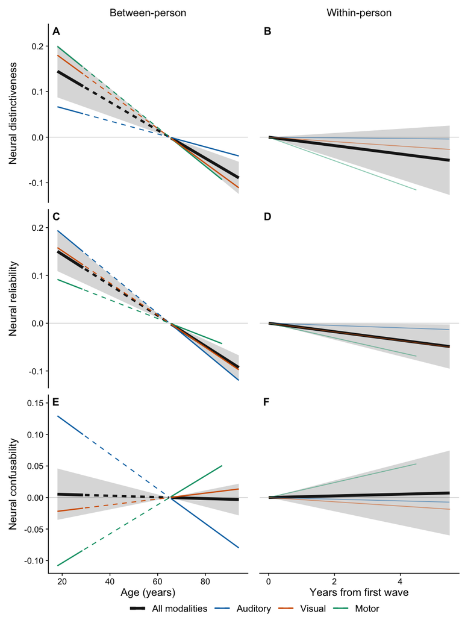

```r
models_primary <- list(
  Distinctiveness = model_primary_distinctiveness,
  Reliability = model_primary_reliability,
  Confusability = model_primary_confusability
)
vis_models_primary <- list(
  Distinctiveness = vis_model_primary_distinctiveness,
  Reliability = vis_model_primary_reliability,
  Confusability = vis_model_primary_confusability
)

between_person_data_primary <- between_person_plot_data(analysis_primary, models_primary, vis_models_primary)
within_person_data_primary <- within_person_plot_data(analysis_primary, models_primary, vis_models_primary)
combined_lines_primary <- combined_plot_data(between_person_data_primary, within_person_data_primary)

figure_2 <- build_combined_figure(
  combined_lines_primary, combined_pooled_slopes(table_2, RULE_LABEL_PRIMARY), centred = TRUE
)
invisible(verify_combined_figure(figure_2, combined_lines_primary))
figure_2_grob <- add_column_axis_titles(figure_2)
grid::grid.newpage(); grid::grid.draw(figure_2_grob)
```

```r
save_manuscript_figure(figure_2_grob, FIGURE_DIR, "figure_2",
                       height_mm = COMBINED_HEIGHT_MM, width_mm = COMBINED_WIDTH_MM)
```

```
## [1] "/Users/ttiyang/Library/CloudStorage/OneDrive-Umich/Projects/MiND/Git/Reliability-Paper/output/figures/figure_2.pdf"
## [2] "/Users/ttiyang/Library/CloudStorage/OneDrive-Umich/Projects/MiND/Git/Reliability-Paper/output/figures/figure_2.png"
```

```r
write_figure_caption(combined_caption("Figure 2", RULE_LABEL_PRIMARY), FIGURE_DIR, "figure_2")
```

```
## [1] "/Users/ttiyang/Library/CloudStorage/OneDrive-Umich/Projects/MiND/Git/Reliability-Paper/output/figures/figure_2_caption.txt"
```

# 13 Figure 3

The pooled magnitude contrast, primary rule: `delta = |b_R| - |b_C|` for both age terms, with its 95% bootstrap percentile interval, read directly from `magnitude_comparison.csv`. Only the pooled contrast is plotted; no modality-specific magnitude contrast is computed or shown anywhere in this document.

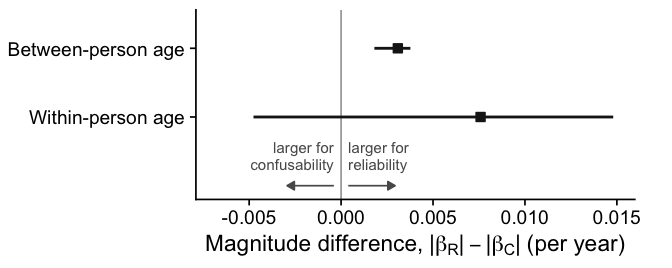

```r
magnitude_data_primary <- magnitude_plot_data(
  magnitude_comparison %>% filter(motion_rule == RULE_LABEL_PRIMARY)
)
figure_3 <- build_magnitude_figure(magnitude_data_primary)
print(figure_3)
```

```r
save_manuscript_figure(figure_3, FIGURE_DIR, "figure_3",
                       height_mm = MAGNITUDE_HEIGHT_MM, width_mm = MAGNITUDE_WIDTH_MM)
```

```
## [1] "/Users/ttiyang/Library/CloudStorage/OneDrive-Umich/Projects/MiND/Git/Reliability-Paper/output/figures/figure_3.pdf"
## [2] "/Users/ttiyang/Library/CloudStorage/OneDrive-Umich/Projects/MiND/Git/Reliability-Paper/output/figures/figure_3.png"
```

```r
write_figure_caption(
  magnitude_caption(magnitude_data_primary, "Figure 3", RULE_LABEL_PRIMARY), FIGURE_DIR, "figure_3"
)
```

```
## [1] "/Users/ttiyang/Library/CloudStorage/OneDrive-Umich/Projects/MiND/Git/Reliability-Paper/output/figures/figure_3_caption.txt"
```

# 14 Figure S1

Figure 2 under the liberal motion rule.

```r
vis_data_liberal <- analysis_liberal %>%
  mutate(
    Modality = factor(
      recode(as.character(Modality), Aud = "Auditory", Vis = "Visual", Mot = "Motor"),
      levels = INTERACTION_MODALITY_LEVELS
    )
  ) %>%
  drop_na(all_of(c(OUTCOMES, "between_cAge", "within_cAge", "Sex_M1", "Education", "SubNum", "Modality")))
contrasts(vis_data_liberal$Modality) <- "contr.sum"

vis_model_liberal_distinctiveness <- lmerTest::lmer(
  Distinctiveness ~ (between_cAge + within_cAge) * Modality + Sex_M1 + Education + (1 | SubNum),
  data = vis_data_liberal, REML = FALSE
)
vis_model_liberal_reliability <- lmerTest::lmer(
  Reliability ~ (between_cAge + within_cAge) * Modality + Sex_M1 + Education + (1 | SubNum),
  data = vis_data_liberal, REML = FALSE
)
vis_model_liberal_confusability <- lmerTest::lmer(
  Confusability ~ (between_cAge + within_cAge) * Modality + Sex_M1 + Education + (1 | SubNum),
  data = vis_data_liberal, REML = FALSE
)
```

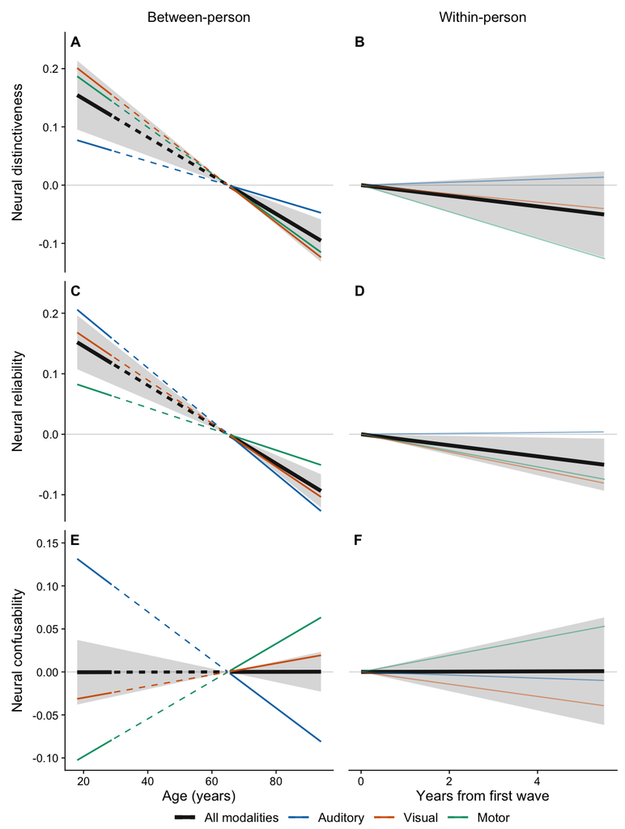

```r
models_liberal <- list(
  Distinctiveness = model_liberal_distinctiveness,
  Reliability = model_liberal_reliability,
  Confusability = model_liberal_confusability
)
vis_models_liberal <- list(
  Distinctiveness = vis_model_liberal_distinctiveness,
  Reliability = vis_model_liberal_reliability,
  Confusability = vis_model_liberal_confusability
)

between_person_data_liberal <- between_person_plot_data(analysis_liberal, models_liberal, vis_models_liberal)
within_person_data_liberal <- within_person_plot_data(analysis_liberal, models_liberal, vis_models_liberal)
combined_lines_liberal <- combined_plot_data(between_person_data_liberal, within_person_data_liberal)

figure_s1 <- build_combined_figure(
  combined_lines_liberal, combined_pooled_slopes(table_s4, RULE_LABEL_LIBERAL), centred = TRUE
)
invisible(verify_combined_figure(figure_s1, combined_lines_liberal))
figure_s1_grob <- add_column_axis_titles(figure_s1)
grid::grid.newpage(); grid::grid.draw(figure_s1_grob)
```

```r
save_manuscript_figure(figure_s1_grob, FIGURE_DIR, "figure_s1",
                       height_mm = COMBINED_HEIGHT_MM, width_mm = COMBINED_WIDTH_MM)
```

```
## [1] "/Users/ttiyang/Library/CloudStorage/OneDrive-Umich/Projects/MiND/Git/Reliability-Paper/output/figures/figure_s1.pdf"
## [2] "/Users/ttiyang/Library/CloudStorage/OneDrive-Umich/Projects/MiND/Git/Reliability-Paper/output/figures/figure_s1.png"
```

```r
write_figure_caption(combined_caption("Figure S1", RULE_LABEL_LIBERAL), FIGURE_DIR, "figure_s1")
```

```
## [1] "/Users/ttiyang/Library/CloudStorage/OneDrive-Umich/Projects/MiND/Git/Reliability-Paper/output/figures/figure_s1_caption.txt"
```

# 15 Figure S2

Figure 3 under the liberal motion rule.

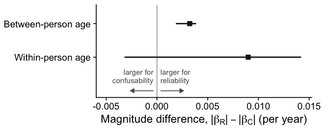

```r
magnitude_data_liberal <- magnitude_plot_data(
  magnitude_comparison %>% filter(motion_rule == RULE_LABEL_LIBERAL)
)
figure_s2 <- build_magnitude_figure(magnitude_data_liberal)
print(figure_s2)
```

```r
save_manuscript_figure(figure_s2, FIGURE_DIR, "figure_s2",
                       height_mm = MAGNITUDE_HEIGHT_MM, width_mm = MAGNITUDE_WIDTH_MM)
```

```
## [1] "/Users/ttiyang/Library/CloudStorage/OneDrive-Umich/Projects/MiND/Git/Reliability-Paper/output/figures/figure_s2.pdf"
## [2] "/Users/ttiyang/Library/CloudStorage/OneDrive-Umich/Projects/MiND/Git/Reliability-Paper/output/figures/figure_s2.png"
```

```r
write_figure_caption(
  magnitude_caption(magnitude_data_liberal, "Figure S2", RULE_LABEL_LIBERAL), FIGURE_DIR, "figure_s2"
)
```

```
## [1] "/Users/ttiyang/Library/CloudStorage/OneDrive-Umich/Projects/MiND/Git/Reliability-Paper/output/figures/figure_s2_caption.txt"
```

# 16 Final validation checks

Independent cross-checks of everything built above, run after the fact so a regression anywhere in the pipeline is caught here rather than discovered by a reader.

```r
# The outcome identity holds row-by-row in the analytic data (it is NOT
# expected to hold between separately-fitted model coefficients -- see
# R/bootstrap.R's header and the manuscript text on additivity).
stopifnot(
  all(abs(analysis_primary$Distinctiveness -
            (analysis_primary$Reliability - analysis_primary$Confusability)) < 1e-8, na.rm = TRUE),
  all(abs(analysis_liberal$Distinctiveness -
            (analysis_liberal$Reliability - analysis_liberal$Confusability)) < 1e-8, na.rm = TRUE)
)
cat("Outcome identity (Distinctiveness = Reliability - Confusability) holds in both analytic datasets.\n")
```

```
## Outcome identity (Distinctiveness = Reliability - Confusability) holds in both analytic datasets.
```

```r
# The Average column of each figure is a summary of the modality columns, so
# it is recomputed from the session x modality observations and compared
# rather than trusted.
print_average_check(between_person_average_check(analysis_primary, between_person_data_primary$points))
```

```
## Between-person figure - Average column
##   definition: participant mean across retained sessions x modalities
##   654 Average points recomputed from the modality columns; max |difference| = 0
##   max |plotted - unweighted mean of that participant's session means| = 0.178
##   session x measure cells: 828; averaged over fewer than 3 modalities: 213 (25.7%)
##   distinct sessions averaged over fewer than 3 modalities: 71
```

```r
print_average_check(within_person_average_check(analysis_primary, within_person_data_primary$points))
```

```
## Within-person figure - Average column
##   definition: per-session mean across retained modalities
##   348 Average points recomputed from the modality columns; max |difference| = 0
##   session x measure cells: 348; averaged over fewer than 3 modalities: 84 (24.1%)
##   distinct sessions averaged over fewer than 3 modalities: 28
```

```r
print_average_check(between_person_average_check(analysis_liberal, between_person_data_liberal$points))
```

```
## Between-person figure - Average column
##   definition: participant mean across retained sessions x modalities
##   678 Average points recomputed from the modality columns; max |difference| = 0
##   max |plotted - unweighted mean of that participant's session means| = 0.0338
##   session x measure cells: 858; averaged over fewer than 3 modalities: 48 (5.6%)
##   distinct sessions averaged over fewer than 3 modalities: 16
```

```r
print_average_check(within_person_average_check(analysis_liberal, within_person_data_liberal$points))
```

```
## Within-person figure - Average column
##   definition: per-session mean across retained modalities
##   360 Average points recomputed from the modality columns; max |difference| = 0
##   session x measure cells: 360; averaged over fewer than 3 modalities: 21 (5.8%)
##   distinct sessions averaged over fewer than 3 modalities: 7
```

```r
# Every manuscript-facing output file this document promises to write.
expected_outputs <- c(
  file.path(TABLE_DIR, c(
    "table_1.csv", "table_2.csv", "table_3.csv", "table_s1.csv", "table_s2.csv",
    "table_s3.csv", "table_s4.csv", "magnitude_comparison.csv",
    "bootstrap_draws_primary.csv", "bootstrap_draws_liberal.csv"
  )),
  file.path(FIGURE_DIR, c(
    "figure_2.png", "figure_2.pdf", "figure_3.png", "figure_3.pdf",
    "figure_s1.png", "figure_s1.pdf", "figure_s2.png", "figure_s2.pdf"
  ))
)
missing_outputs <- expected_outputs[!file.exists(expected_outputs)]
stopifnot(length(missing_outputs) == 0)
cat("All", length(expected_outputs), "manuscript-facing output files were written to output/.\n")
```

```
## All 18 manuscript-facing output files were written to output/.
```